# GWAS: Resistant hypertension

```r
knitr::opts_chunk$set(echo = TRUE, warning=FALSE, message=F)
```

**Libraries**

```r
library(tidyverse)
library(data.table) # fread() function
library(gridExtra)  # plots to grid
library(visdat)     # visualization of tibble and na's
library(kableExtra) # Pretty tables
library(tableone)   # Characteristics table
#install.packages("packages/dotgen_0.1.0.tar.gz", repos=NULL)
#install.packages("packages/qvalue_2.30.0.tar.gz", repos=NULL)
library(slider)
library(fuzzyjoin)
library(bigrquery)

fg_path <- "/finngen/library-red/finngen_R12"
data_path <- "data"
font_size <- 12

source("scripts/functions.R")
```

# 1 Data

## 1.1 Definitions

Our aim is to create a new endpoint for **medication resistant hypertension**. We will read detailed information from different hypertension medicines from drug purchase register and select cases, where minimum four different medicines have been purchased within three months period.

**Included ATC codes:**

- C02
  - Include all, except C02KX
  - Two medicines: Group C02L
- C03
  - Include all.
  - Two medicines: C03E
- C07
  - Include all.
  - Two medicines: Groups C07B, C07C, C07D, C07FB
- C08
  - Include all.
  - Two medicines: Group C08G
- C09
  - Include all.
  - Two medicines: C09BA, C09BB, C09BX02, C09BX05, C09DA, C09DB, C09DX02, C09DX04, C09DX05, C09XA52
  - Three medicines: C09BX01, C09BX03, C09BX04, C09DX01, C09DX03, C09DX06, C09DX07, C09XA54

**Drug classes:**

- Diuretics
- ACE inhibitors (ACEI)
- Angiotensin II receptor blockers (ARB)
- Calcium chanel blockers (CCB)
- Beta blockers (BB)
- Other

**Datasets**

- Count variable NRCL_HT
- Maximum number of different antihypertensive medicine *classes* within 3 months window
- Only persons with diagnosed hypertension I9_HYPTENS and > 0 medicines
- Normalized version: NRCL_HT_INT
- Binary variable RES_HT
- Cases: >= 4 drug classes within 3 months time window *and* I9_HYPTENS.
- Controls: 1 drug purchase and I9_HYPTENS.
- Binary variable RES_HT0
- Cases: >= 4 drug classes within 3 months time window *and* I9_HYPTENS.
- Controls: 0 drug purchases and no I9_HYPTENS.

## 1.2 Create drug use variables

**Copy and preprocess outside the R**

Endpoint file is transfered and unzipped. Entries of interest are selected from endpoint file prior to import to R, because the original phenotype file is very large.

Pattern: grep ‘PURCH’ | grep ’ C0[2,3,7,8,9]’

```bash
phenodir="/finngen/library-red/finngen_R12/phenotype_1.0"
datadir="/home/ivm/res_ht/data"
zgrep 'PURCH\|FINNGENID'  $phenodir/data/finngen_R12_detailed_longitudinal_1.0.txt.gz | grep '\sC0[2,3,7,8,9]\|FINNGENID' | gzip > $datadir/R12_detailed_C0.txt.gz &
```

**Number of drugs per code**

We check if our R12 data has ATC codes missing from our previous R10 based ATC-list. Missing definitions are added by hand to definition file if necessary.

```r
#Read data in.
#df0_test <- fread(str_glue("{data_path}/long_det_fake_filt_test.tsv"))
atc.curr <- fread(str_glue("{data_path}/R12_detailed_C0.txt.gz")) %>%
  select(ATC=CODE1) %>%
  distinct
atc.prev <- fread(str_glue("{data_path}/ATC_codes_r10.csv"))
#atc.prev <- fread(str_glue("{data_path}/ATC_codes_r12.csv"))

atc.curr %>%  anti_join(atc.prev, by="ATC")
```

**Moving sum of drug purchases**

First we calculate moving sum for drug purchases within the 3 months window. Then we create file for cases in ‘endpoint format’.

Searching unique medicines and handling strings in each window is slow, so this is run as a separate Rscript.

```bash
Rscript scripts/gen_res_r12.R &
```

# 2 Data: All ages

Read in phenotype data

```r
# Scope and project id to BigQuery
bq_auth(scopes="https://www.googleapis.com/auth/bigquery")
projectid = "fg-production-sandbox-20"

#Tables
table_ep = "finngen-production-library.sandbox_tools_r12.endpoint_cohorts_r12_v1"
table_min = "finngen-production-library.sandbox_tools_r12.minimum_extended_r12_v1"

#vars_download <-  c("I9_HYPTENS","DEATH")
vars_download <- fread("scripts/fg_pheno_short.txt", header = F) %>% pull(V1)

phenotypes <- load_fg_variables(vars_download, table_ep, table_min, projectid )
fwrite(phenotypes, "data/finngen_R12_HT.txt.gz", sep="\t")

phenotypes %>% summary()
```

Analysis covariates:

```r
covs_tmp <- fread(str_glue("{fg_path}/analysis_covariates/R12_COV_PHENO_V2.FID.txt.gz")) %>%
  select(FID, IID, SEX_IMPUTED, AGE_AT_DEATH_OR_END_OF_FOLLOWUP, starts_with("PC"), IS_FINNGEN2_CHIP, contains("_norm", ignore.case = F))

fwrite(covs_tmp, str_glue("{data_path}/gwas_covs_r12.txt.gz"), sep="\t")
```

## 2.1 Combine and preprocess

The input file for the new enpoints includes only events with NRMED_MAX > 0. When combined with full fenotype file NA’s are introduced. These are replaced with values when appropriate.

```r
#endpoints and covariates
phenotypes <- fread(str_glue("{data_path}/finngen_R12_HT.txt.gz"))
htres <- fread(str_glue("{data_path}/nrmed_max_r12.tsv.gz"))
phenomin <- fread(str_glue("{fg_path}/phenotype_1.0/data/finngen_R12_minimum_1.0.txt.gz"))
covs_in <- fread(str_glue("{data_path}/gwas_covs_r12.txt.gz")) %>%
  rename(FINNGENID = FID) %>%     #At this point we just want sex.  Other GWAS covariates later
  select(FINNGENID, SEX_IMPUTED)

#HT_RES and HT_RES_CL were originally created in script gen_res_ht.R as moving sum, and not here, because that's only way to get age and year correct. For example in case where nrmed_max == 6, we should use age when nrmed_max==5 is first time reached, not when maximum is reached.

#After definitions changed, whe do not use anymore original HT_RES or HT_RES_CL, but new variables which are created at this step. We omit age and year variables for them. Age is needed for outcomes, not for exposures.

df_all <- phenomin %>%
  left_join(covs_in, by = "FINNGENID") %>%   #This represent official genotyped dataset
  left_join(htres, by = "FINNGENID") %>%
  left_join(select(phenotypes, -BL_AGE, -BL_YEAR, -SEX), by = "FINNGENID") %>%

  mutate(
         female = SEX_IMPUTED,

         #These include all values; all values I9_HYPTENS are allowed. For NRMED_MAX NA's are set as 0.
         NRMED_MAX = if_else(is.na(NRMED_MAX), 0L, NRMED_MAX),
         NRMED_MAX_AGE = if_else(NRMED_MAX == 0, NA_real_, NRMED_MAX_AGE),
         NRMED_MAX_YEAR = if_else(NRMED_MAX == 0, NA_integer_, NRMED_MAX_YEAR),
         NRCLASS_MAX = if_else(is.na(NRCLASS_MAX), 0L, NRCLASS_MAX),
         NRCLASS_MAX_AGE = if_else(NRCLASS_MAX == 0, NA_real_, NRCLASS_MAX_AGE),
         NRCLASS_MAX_YEAR = if_else(NRCLASS_MAX == 0, NA_integer_, NRCLASS_MAX_YEAR),

         #These include only values where I9_HYPTENS == 1 and NRMED_MAX > 0, rest are set as NA
         NRMED_HT = if_else(I9_HYPTENS == 1 & NRMED_MAX > 0, NRMED_MAX, NA_integer_),
         NRMED_HT_AGE = if_else(I9_HYPTENS == 1, NRMED_MAX_AGE, NA_real_),
         NRMED_HT_YEAR = if_else(I9_HYPTENS == 1, NRMED_MAX_YEAR, NA_integer_),
         NRCL_HT = if_else(I9_HYPTENS == 1 & NRCLASS_MAX > 0, NRCLASS_MAX, NA_integer_),
         NRCL_HT_AGE = if_else(I9_HYPTENS == 1, NRCLASS_MAX_AGE, NA_real_),
         NRCL_HT_YEAR = if_else(I9_HYPTENS == 1, NRCLASS_MAX_YEAR, NA_integer_),

           #Two class variable/mild HT as control
         RES_HT = case_when(
           NRCLASS_MAX == 1 & I9_HYPTENS == 1 ~ 0L,
           NRCLASS_MAX >= 4 & I9_HYPTENS == 1 ~ 1L,
           TRUE ~ NA_integer_
         ),

         #Two class variable/healthy control
         RES_HT0 = case_when(
           NRCLASS_MAX == 0 & I9_HYPTENS == 0 ~ 0L,
           NRCLASS_MAX >= 4 & I9_HYPTENS == 1 ~ 1L,
           TRUE ~ NA_integer_
         ),

         #Three class variable from variables above
         RES3_HT0 = case_when(
           NRCLASS_MAX == 0 & I9_HYPTENS == 0 ~ "Healthy",
           NRCLASS_MAX == 1 & I9_HYPTENS == 1 ~ "Mild",
           NRCLASS_MAX >= 4 & I9_HYPTENS == 1 ~ "Resistant",
           TRUE ~ NA_character_
         ) %>% factor(levels=c("Healthy", "Mild", "Resistant")),


         #Wider definition of hypercholesterolaemia, includes also statin medication
         HYPCHOL_WIDE = if_else(E4_HYPERCHOL == 1 | RX_STATIN ==1, 1, 0)) %>%

  rowwise() %>%
  mutate(HYPCHOL_WIDE_AGE = min(E4_HYPERCHOL_AGE,RX_STATIN_AGE)) %>%
  ungroup() %>%
  relocate(c(contains("I9_"),contains("RX_")), .after = last_col()) %>%
  rename_at(vars(contains('I9_')), list(~str_remove(., "I9_"))) %>%
  rename_at(vars(contains('RX_')), list(~str_remove(., "RX_"))) %>%
  rename_at(vars(contains('E4_')), list(~str_remove(., "E4_"))) %>%
  rename_at(vars(contains('N14_')), list(~str_remove(., "N14_"))) %>%
  rename_at(vars(contains('F5_')), list(~str_remove(., "F5_")))  %>%

  #NA's in disease covariates set as 0. These NA's represent similar variables,
  #are present for GWASes and are not relevant for us.
  mutate_at(c( "DIABETES", "OBESITY", "HYPCHOL_WIDE"), as.integer) %>%
  mutate_at(c( "DIABETES", "OBESITY", "HYPCHOL_WIDE"), ~if_else(is.na(.), 0L, .))

#Remove individuals with no SEX_IMPUTED - they don't have genetic covariates
df <- df_all %>% filter(!is.na(female))
```

## 2.2 Rank based inverse normal transformation

We will run direct rank based inverse normal transformation (INT) directly to our count phenotype (direct INT). Even this transformation is meant for continuous data, in some earlier publications it is used also for count data.

```r
df <- df %>%
  mutate(NRCLASS_INT = qnorm((rank(NRCLASS_MAX,na.last="keep")-0.5)/sum(!is.na(NRCLASS_MAX))),
         NRCL_HT_INT = qnorm((rank(NRCL_HT,na.last="keep")-0.5)/sum(!is.na(NRCL_HT)))
         )
```

**Transformed count variables**

Summary statistics, histograms and CDFs.

```r
#Huomaa, että seurantaa alkaa vuodesta 1994!!!

df %>%
  select(NRCLASS_INT, NRCL_HT_INT)%>%
  #mutate_all(as.factor) %>%
  summary()
```

```
##   NRCLASS_INT        NRCL_HT_INT
##  Min.   :-0.88885   Min.   :-1.6
##  1st Qu.:-0.88885   1st Qu.:-0.7
##  Median :-0.03626   Median : 0.2
##  Mean   : 0.03969   Mean   : 0.0
##  3rd Qu.: 0.47423   3rd Qu.: 1.0
##  Max.   : 3.31290   Max.   : 3.0
##                     NA's   :347325
```

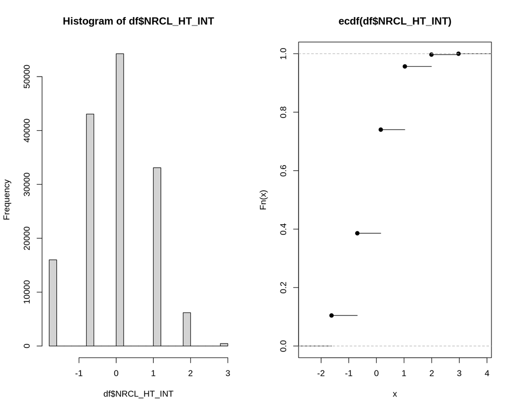

```r
par(mfrow=c(1,2))
hist(df$NRCL_HT_INT)
ecdf(df$NRCL_HT_INT) %>% plot()
```

```r
par(mfrow=c(1,1))
```

## 2.3 Characteristics

**Number of individuals**

```r
#Note: Followup for drug pruchase register starts from year 1994

#Number of individuals:
c("Number of all R12 individuals:", dim(phenomin)[1])
```

```
## [1] "Number of all R12 individuals:" "520210"
```

```r
c("Number of individuals at 'endpoint file':", dim(phenotypes)[1])
```

```
## [1] "Number of individuals at 'endpoint file':"
## [2] "520210"
```

**Summary, all data**

```r
df_all %>% mutate_if(is.character, as.factor) %>% mutate_at(c("FINNGENID"), as.character) %>% summary()
```

```
##   FINNGENID         APPROX_BIRTH_DATE       BL_YEAR         BL_AGE
##  Length:520210      Min.   :1896-08-26   Min.   :1970   Min.   :  0.00
##  Class :character   1st Qu.:1947-01-05   1st Qu.:2011   1st Qu.: 39.20
##  Mode  :character   Median :1959-09-06   Median :2018   Median : 55.45
##                     Mean   :1961-06-05   Mean   :2014   Mean   : 52.85
##                     3rd Qu.:1976-01-28   3rd Qu.:2020   3rd Qu.: 66.67
##                     Max.   :2022-10-14   Max.   :2023   Max.   :104.85
##                                          NA's   :827    NA's   :827
##      SEX             HEIGHT         HEIGHT_AGE         WEIGHT
##  female:293373   Min.   : 44.0    Min.   : 2.0     Min.   :  3.00
##  male  :226837   1st Qu.:163.0    1st Qu.:48.5     1st Qu.: 67.00
##                  Median :170.0    Median :57.6     Median : 78.00
##                  Mean   :169.8    Mean   :56.3     Mean   : 79.15
##                  3rd Qu.:177.0    3rd Qu.:66.7     3rd Qu.: 90.00
##                  Max.   :218.0    Max.   :98.9     Max.   :256.00
##                  NA's   :140928   NA's   :378460   NA's   :135238
##    WEIGHT_AGE          BMI          SMOKE2           SMOKE3
##  Min.   : 2.0     Min.   :10.00    no  :240024   current: 80787
##  1st Qu.:48.8     1st Qu.:23.60    yes : 83444   former : 70362
##  Median :59.4     Median :26.50    NA's:196742   never  :156437
##  Mean   :57.3     Mean   :27.31                  NA's   :212624
##  3rd Qu.:68.0     3rd Qu.:30.10
##  Max.   :98.9     Max.   :79.50
##  NA's   :379025   NA's   :143310
##         SMOKE5       CURRENT_SMOKER    EVER_SMOKER       SMOKE_AGE
##  current   : 11204   Min.   :0.00     Min.   :0.00     Min.   : 5.0
##  former    : 12823   1st Qu.:0.00     1st Qu.:0.00     1st Qu.:43.0
##  never     : 31293   Median :0.00     Median :0.00     Median :55.9
##  occasional:  2236   Mean   :0.34     Mean   :0.49     Mean   :53.5
##  quitter   :   845   3rd Qu.:1.00     3rd Qu.:1.00     3rd Qu.:65.1
##  NA's      :461809   Max.   :1.00     Max.   :1.00     Max.   :99.1
##                      NA's   :282981   NA's   :212619   NA's   :422651
##  regionofbirth             regionofbirthname   movedabroad
##  Min.   :   1.0   Uusimaa           : 97023   Min.   :1
##  1st Qu.:   2.0   Varsinais-Suomi   : 52800   1st Qu.:1
##  Median :   9.0   North Ostrobothnia: 44570   Median :1
##  Mean   : 188.1   Pirkanmaa         : 43623   Mean   :1
##  3rd Qu.:  14.0   Pohjois-Savo      : 38073   3rd Qu.:1
##  Max.   :9999.0   (Other)           :243205   Max.   :1
##  NA's   :916      NA's              :   916   NA's   :518484
```

[output cut: 129 more lines]

```
##  Min.   :1938     Min.   :0.0000   Min.   :0.0000   Min.   :  0.036
##  1st Qu.:2001     1st Qu.:0.0000   1st Qu.:0.0000   1st Qu.: 41.010
##  Median :2011     Median :1.0000   Median :0.0000   Median : 53.116
##  Mean   :2008     Mean   :0.5408   Mean   :0.3634   Mean   : 52.350
##  3rd Qu.:2018     3rd Qu.:1.0000   3rd Qu.:1.0000   3rd Qu.: 63.630
##  Max.   :2023     Max.   :1.0000   Max.   :1.0000   Max.   :105.980
##  NA's   :511320
##    STATIN_AGE       ANTIHYP_YEAR     STATIN_YEAR
##  Min.   :  0.036   Min.   :1992     Min.   :1995
##  1st Qu.: 44.935   1st Qu.:1998     1st Qu.:2004
##  Median : 57.230   Median :2006     Median :2009
##  Mean   : 56.069   Mean   :2006     Mean   :2009
##  3rd Qu.: 67.594   3rd Qu.:2013     3rd Qu.:2016
##  Max.   :107.458   Max.   :2022     Max.   :2022
##                    NA's   :238886   NA's   :331152
```

```r
c("Number of individuals, with genetic covariates:", dim(covs_in)[1])
```

```
## [1] "Number of individuals, with genetic covariates:"
## [2] "500348"
```

```r
tmp <- df_all %>%
  filter(HYPTENS == 1)
c("Number of all hypertensive individuals:", dim(tmp)[1])
```

```
## [1] "Number of all hypertensive individuals:"
## [2] "158906"
```

**Summary, All hypertensive individuals**

```r
tmp%>% mutate_if(is.character, as.factor) %>% mutate_at(c("FINNGENID"), as.character) %>% summary()
```

```
##   FINNGENID         APPROX_BIRTH_DATE       BL_YEAR         BL_AGE
##  Length:158906      Min.   :1896-08-26   Min.   :1975   Min.   :  0.12
##  Class :character   1st Qu.:1939-03-15   1st Qu.:2005   1st Qu.: 56.47
##  Mode  :character   Median :1947-08-11   Median :2018   Median : 65.16
##                     Mean   :1948-06-06   Mean   :2012   Mean   : 63.94
##                     3rd Qu.:1956-08-25   3rd Qu.:2020   3rd Qu.: 72.96
##                     Max.   :2020-10-30   Max.   :2023   Max.   :104.85
##                                          NA's   :454    NA's   :454
##      SEX            HEIGHT        HEIGHT_AGE         WEIGHT
##  female:76450   Min.   : 52.0   Min.   : 8.07    Min.   :  3.00
##  male  :82456   1st Qu.:163.0   1st Qu.:55.07    1st Qu.: 71.00
##                 Median :170.0   Median :62.53    Median : 82.00
##                 Mean   :169.8   Mean   :62.95    Mean   : 84.07
##                 3rd Qu.:177.0   3rd Qu.:71.14    3rd Qu.: 94.00
##                 Max.   :213.0   Max.   :98.90    Max.   :249.00
##                 NA's   :38827   NA's   :104681   NA's   :36236
##    WEIGHT_AGE          BMI         SMOKE2          SMOKE3
##  Min.   : 8.07    Min.   :11.1    no  :72341   current:26559
##  1st Qu.:57.11    1st Qu.:25.3    yes :27055   former :24300
##  Median :64.07    Median :28.3    NA's:59510   never  :45468
##  Mean   :64.09    Mean   :29.1                 NA's   :62579
##  3rd Qu.:71.77    3rd Qu.:32.0
##  Max.   :98.90    Max.   :79.5
##  NA's   :104874   NA's   :39486
##         SMOKE5       CURRENT_SMOKER   EVER_SMOKER      SMOKE_AGE
##  current   :  3254   Min.   :0.00    Min.   :0.00    Min.   :14.48
##  former    :  4797   1st Qu.:0.00    1st Qu.:0.00    1st Qu.:54.47
##  never     :  9924   Median :0.00    Median :1.00    Median :61.61
##  occasional:   495   Mean   :0.37    Mean   :0.53    Mean   :61.90
##  quitter   :   197   3rd Qu.:1.00    3rd Qu.:1.00    3rd Qu.:70.44
##  NA's      :140239   Max.   :1.00    Max.   :1.00    Max.   :99.06
##                      NA's   :86879   NA's   :62579   NA's   :126643
##  regionofbirth             regionofbirthname  movedabroad
##  Min.   :   1.0   Uusimaa           :23837   Min.   :1
##  1st Qu.:   4.0   Varsinais-Suomi   :15288   1st Qu.:1
##  Median :  10.0   Pirkanmaa         :13749   Median :1
##  Mean   : 339.5   North Ostrobothnia:13299   Mean   :1
##  3rd Qu.:  14.0   Pohjois-Savo      :13255   3rd Qu.:1
##  Max.   :9999.0   (Other)           :79358   Max.   :1
##  NA's   :120      NA's              :  120   NA's   :158776
```

[output cut: 129 more lines]

```
##  Min.   :0.0000   Min.   :0.0000   Min.   :  0.066   Min.   :  2.346
##  1st Qu.:1.0000   1st Qu.:0.0000   1st Qu.: 47.312   1st Qu.: 55.468
##  Median :1.0000   Median :1.0000   Median : 55.251   Median : 63.510
##  Mean   :0.9773   Mean   :0.6656   Mean   : 55.256   Mean   : 63.712
##  3rd Qu.:1.0000   3rd Qu.:1.0000   3rd Qu.: 63.561   3rd Qu.: 72.259
##  Max.   :1.0000   Max.   :1.0000   Max.   :103.918   Max.   :105.939
##
##   ANTIHYP_YEAR   STATIN_YEAR
##  Min.   :1992   Min.   :1995
##  1st Qu.:1995   1st Qu.:2002
##  Median :2002   Median :2007
##  Mean   :2003   Mean   :2008
##  3rd Qu.:2009   3rd Qu.:2013
##  Max.   :2022   Max.   :2022
##  NA's   :3607   NA's   :53141
```

```r
tmp <- df %>%
  filter(HYPTENS == 1)
c("Number of all hypertensive individuals with genetic covariates:", dim(tmp)[1])
```

```
## [1] "Number of all hypertensive individuals with genetic covariates:"
## [2] "154630"
```

**Summary, hypertensive with genetic covariates**

```r
tmp %>% mutate_if(is.character, as.factor) %>% mutate_at(c("FINNGENID"), as.character) %>% summary()
```

```
##   FINNGENID         APPROX_BIRTH_DATE       BL_YEAR         BL_AGE
##  Length:154630      Min.   :1896-08-26   Min.   :1975   Min.   :  0.12
##  Class :character   1st Qu.:1939-03-23   1st Qu.:2005   1st Qu.: 56.56
##  Mode  :character   Median :1947-08-12   Median :2018   Median : 65.27
##                     Mean   :1948-05-31   Mean   :2012   Mean   : 64.03
##                     3rd Qu.:1956-08-10   3rd Qu.:2020   3rd Qu.: 73.00
##                     Max.   :2020-10-30   Max.   :2023   Max.   :104.85
##                                          NA's   :445    NA's   :445
##      SEX            HEIGHT        HEIGHT_AGE         WEIGHT
##  female:74397   Min.   : 52.0   Min.   : 8.07    Min.   :  3.00
##  male  :80233   1st Qu.:163.0   1st Qu.:55.17    1st Qu.: 72.00
##                 Median :170.0   Median :62.70    Median : 82.00
##                 Mean   :169.8   Mean   :63.09    Mean   : 84.14
##                 3rd Qu.:177.0   3rd Qu.:71.28    3rd Qu.: 94.00
##                 Max.   :213.0   Max.   :98.90    Max.   :249.00
##                 NA's   :38010   NA's   :102121   NA's   :35499
##    WEIGHT_AGE          BMI         SMOKE2          SMOKE3
##  Min.   : 8.07    Min.   :11.10   no  :70218   current:25789
##  1st Qu.:57.27    1st Qu.:25.30   yes :26275   former :23579
##  Median :64.25    Median :28.30   NA's:58137   never  :44110
##  Mean   :64.24    Mean   :29.11                NA's   :61152
##  3rd Qu.:71.88    3rd Qu.:32.00
##  Max.   :98.90    Max.   :79.50
##  NA's   :102311   NA's   :38661
##         SMOKE5       CURRENT_SMOKER   EVER_SMOKER      SMOKE_AGE
##  current   :  3171   Min.   :0.00    Min.   :0.00    Min.   :14.48
##  former    :  4684   1st Qu.:0.00    1st Qu.:0.00    1st Qu.:54.50
##  never     :  9694   Median :0.00    Median :1.00    Median :61.64
##  occasional:   481   Mean   :0.37    Mean   :0.53    Mean   :61.94
##  quitter   :   188   3rd Qu.:1.00    3rd Qu.:1.00    3rd Qu.:70.44
##  NA's      :136412   Max.   :1.00    Max.   :1.00    Max.   :99.06
##                      NA's   :84731   NA's   :61152   NA's   :123008
##  regionofbirth             regionofbirthname  movedabroad
##  Min.   :   1.0   Uusimaa           :23217   Min.   :1
##  1st Qu.:   4.0   Varsinais-Suomi   :15038   1st Qu.:1
##  Median :  10.0   Pirkanmaa         :13613   Median :1
##  Mean   : 330.8   North Ostrobothnia:13129   Mean   :1
##  3rd Qu.:  14.0   Pohjois-Savo      :13127   3rd Qu.:1
##  Max.   :9999.0   (Other)           :76389   Max.   :1
##  NA's   :117      NA's              :  117   NA's   :154521
```

[output cut: 129 more lines]

```
##  Min.   :0.0000   Min.   :0.0000   Min.   :  0.066   Min.   :  2.346
##  1st Qu.:1.0000   1st Qu.:0.0000   1st Qu.: 47.303   1st Qu.: 55.484
##  Median :1.0000   Median :1.0000   Median : 55.227   Median : 63.519
##  Mean   :0.9775   Mean   :0.6658   Mean   : 55.234   Mean   : 63.722
##  3rd Qu.:1.0000   3rd Qu.:1.0000   3rd Qu.: 63.520   3rd Qu.: 72.248
##  Max.   :1.0000   Max.   :1.0000   Max.   :103.918   Max.   :105.939
##
##   ANTIHYP_YEAR   STATIN_YEAR     NRCLASS_INT       NRCL_HT_INT
##  Min.   :1992   Min.   :1995    Min.   :-0.8889   Min.   :-1.6233
##  1st Qu.:1995   1st Qu.:2002    1st Qu.: 0.4742   1st Qu.:-0.6898
##  Median :2002   Median :2007    Median : 0.9932   Median : 0.1588
##  Mean   :2003   Mean   :2008    Mean   : 0.9241   Mean   : 0.0047
##  3rd Qu.:2008   3rd Qu.:2013    3rd Qu.: 1.6334   3rd Qu.: 1.0298
##  Max.   :2022   Max.   :2022    Max.   : 3.3129   Max.   : 2.9698
##  NA's   :3478   NA's   :51678                     NA's   :1607
```

```r
#We don't have corresponding set in UKBB replication
tmp <- df %>%
  filter(HYPTENS == 1, NRMED_MAX > 0)
c("Number of all hypertensive individuals with medication and with genetic covariates:", dim(tmp)[1])
```

```
## [1] "Number of all hypertensive individuals with medication and with genetic covariates:"
## [2] "153023"
```

**Summary, hypertensive with genetic covariates and with one medication**

```r
tmp %>% mutate_if(is.character, as.factor) %>% mutate_at(c("FINNGENID"), as.character) %>% summary()
```

```
##   FINNGENID         APPROX_BIRTH_DATE       BL_YEAR         BL_AGE
##  Length:153023      Min.   :1896-08-26   Min.   :1975   Min.   :  0.19
##  Class :character   1st Qu.:1939-04-16   1st Qu.:2005   1st Qu.: 56.62
##  Mode  :character   Median :1947-08-14   Median :2018   Median : 65.31
##                     Mean   :1948-06-03   Mean   :2012   Mean   : 64.09
##                     3rd Qu.:1956-07-24   3rd Qu.:2020   3rd Qu.: 73.03
##                     Max.   :2020-10-30   Max.   :2023   Max.   :104.85
##                                          NA's   :440    NA's   :440
##      SEX            HEIGHT        HEIGHT_AGE         WEIGHT
##  female:73763   Min.   : 57.0   Min.   : 8.07    Min.   :  5.00
##  male  :79260   1st Qu.:163.0   1st Qu.:55.20    1st Qu.: 72.00
##                 Median :170.0   Median :62.79    Median : 82.00
##                 Mean   :169.8   Mean   :63.15    Mean   : 84.19
##                 3rd Qu.:177.0   3rd Qu.:71.35    3rd Qu.: 94.00
##                 Max.   :213.0   Max.   :98.90    Max.   :249.00
##                 NA's   :37674   NA's   :101126   NA's   :35181
##    WEIGHT_AGE          BMI         SMOKE2          SMOKE3
##  Min.   : 8.07    Min.   :11.10   no  :69685   current:25256
##  1st Qu.:57.27    1st Qu.:25.30   yes :25739   former :23413
##  Median :64.27    Median :28.30   NA's:57599   never  :43756
##  Mean   :64.28    Mean   :29.13                NA's   :60598
##  3rd Qu.:71.93    3rd Qu.:32.00
##  Max.   :98.90    Max.   :79.50
##  NA's   :101317   NA's   :38319
##         SMOKE5       CURRENT_SMOKER   EVER_SMOKER      SMOKE_AGE
##  current   :  3130   Min.   :0.00    Min.   :0.00    Min.   :14.48
##  former    :  4646   1st Qu.:0.00    1st Qu.:0.00    1st Qu.:54.51
##  never     :  9594   Median :0.00    Median :1.00    Median :61.70
##  occasional:   474   Mean   :0.37    Mean   :0.53    Mean   :62.01
##  quitter   :   187   3rd Qu.:1.00    3rd Qu.:1.00    3rd Qu.:70.55
##  NA's      :134992   Max.   :1.00    Max.   :1.00    Max.   :99.06
##                      NA's   :84011   NA's   :60598   NA's   :121886
##  regionofbirth             regionofbirthname  movedabroad
##  Min.   :   1.0   Uusimaa           :22983   Min.   :1
##  1st Qu.:   4.0   Varsinais-Suomi   :14905   1st Qu.:1
##  Median :  10.0   Pirkanmaa         :13498   Median :1
##  Mean   : 329.4   Pohjois-Savo      :13029   Mean   :1
##  3rd Qu.:  14.0   North Ostrobothnia:13005   3rd Qu.:1
##  Max.   :9999.0   (Other)           :75488   Max.   :1
##  NA's   :115      NA's              :  115   NA's   :152922
```

[output cut: 129 more lines]

```
##  Min.   :0.0000   Min.   :0.0000   Min.   :  0.066   Min.   :  2.346
##  1st Qu.:1.0000   1st Qu.:0.0000   1st Qu.: 47.254   1st Qu.: 55.487
##  Median :1.0000   Median :1.0000   Median : 55.145   Median : 63.501
##  Mean   :0.9878   Mean   :0.6707   Mean   : 55.121   Mean   : 63.721
##  3rd Qu.:1.0000   3rd Qu.:1.0000   3rd Qu.: 63.369   3rd Qu.: 72.221
##  Max.   :1.0000   Max.   :1.0000   Max.   :103.918   Max.   :105.939
##
##   ANTIHYP_YEAR   STATIN_YEAR     NRCLASS_INT        NRCL_HT_INT
##  Min.   :1992   Min.   :1995    Min.   :-0.03626   Min.   :-1.62326
##  1st Qu.:1995   1st Qu.:2002    1st Qu.: 0.47423   1st Qu.:-0.68975
##  Median :2002   Median :2007    Median : 0.99320   Median : 0.15875
##  Mean   :2003   Mean   :2008    Mean   : 0.94317   Mean   : 0.00468
##  3rd Qu.:2008   3rd Qu.:2013    3rd Qu.: 1.63345   3rd Qu.: 1.02980
##  Max.   :2022   Max.   :2022    Max.   : 3.31290   Max.   : 2.96980
##  NA's   :1871   NA's   :50395
```

**Count variables**

Summary statistics and histograms.

- NRCLASS_MAX: Number of hypertensive drug classes, including healthy individuals
- NRCLASS_MAX: Number of hypertensive drug classes, excluding healthy individuals

```r
#htres %>%
#  mutate_at(c("NRMED_MAX", "NRCLASS_MAX", "HTRES", "HTRES_CL"), as.factor) %>%
#  summary()

df %>%
  select(starts_with("NRCLASS_MAX"), starts_with("NRCL_HT")) %>%
  #mutate_at(c("NRMED_MAX", "NRCLASS_MAX", "HTRES", "HTRES_CL"), as.factor) %>%
  summary()
```

```
##   NRCLASS_MAX    NRCLASS_MAX_AGE  NRCLASS_MAX_YEAR    NRCL_HT
##  Min.   :0.000   Min.   :  0.05   Min.   :1992     Min.   :1.0
##  1st Qu.:0.000   1st Qu.: 48.30   1st Qu.:2006     1st Qu.:2.0
##  Median :1.000   Median : 59.14   Median :2013     Median :3.0
##  Mean   :1.365   Mean   : 57.71   Mean   :2012     Mean   :2.8
##  3rd Qu.:2.000   3rd Qu.: 69.34   3rd Qu.:2019     3rd Qu.:4.0
##  Max.   :6.000   Max.   :102.69   Max.   :2023     Max.   :6.0
##                  NA's   :187171   NA's   :187171   NA's   :347325
##   NRCL_HT_AGE      NRCL_HT_YEAR     NRCL_HT_INT
##  Min.   :  0.1    Min.   :1992     Min.   :-1.6
##  1st Qu.: 54.3    1st Qu.:2005     1st Qu.:-0.7
##  Median : 63.1    Median :2011     Median : 0.2
##  Mean   : 62.5    Mean   :2010     Mean   : 0.0
##  3rd Qu.: 71.8    3rd Qu.:2017     3rd Qu.: 1.0
##  Max.   :100.2    Max.   :2023     Max.   : 3.0
##  NA's   :347325   NA's   :347325   NA's   :347325
```

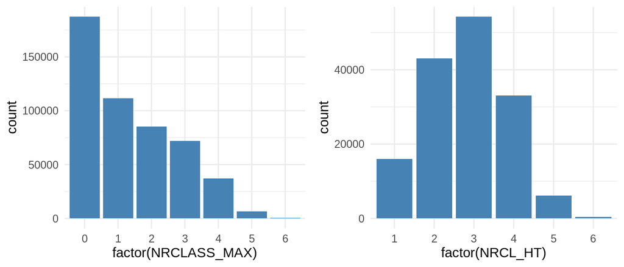

```r
p1 <- ggplot(df, aes(x=factor(NRCLASS_MAX)))+
  geom_bar(stat="count",  fill="steelblue") +
  theme_minimal()

p2 <- ggplot(df, aes(x=factor(NRCL_HT)))+
  geom_bar(stat="count",  fill="steelblue") +
  scale_x_discrete(na.translate = FALSE) +
  theme_minimal()

grid.arrange(p1, p2, ncol=2)
```

**Levels and some correlations**

```r
#For count variables: if count ==0,  *_AGE = NA
tmp1 <- table(df$NRMED_MAX)
tmp1[tmp1<5] <-NA
tmp1
```

```
##
##      0      1      2      3      4      5      6      7      8      9     10
## 187171  99797  75575  61792  42277  22208   8225   2393    694    174     35
##     11     12     16
##
```

```r
tmpHT <- table(df$NRMED_HT)
tmpHT[tmpHT<5] = NA
tmpHT
```

```
##
##     1     2     3     4     5     6     7     8     9    10    11    12    16
## 14317 32180 41484 34482 19764  7634  2287   668   167    34
```

```r
table(df$NRCLASS_MAX)
```

```
##
##      0      1      2      3      4      5      6
## 187171 111533  85399  72071  37125   6587    462
```

```r
table(df$NRCL_HT)
```

```
##
##     1     2     3     4     5     6
## 15996 43043 54247 33092  6189   456
```

```r
cor(df$NRMED_MAX, df$NRCLASS_MAX, use="complete.obs")
```

```
## [1] 0.9638353
```

```r
cor(df$NRMED_HT, df$NRCL_HT, use="complete.obs")
```

```
## [1] 0.8810401
```

**Categorical variables**

Number of cases and controls:

```r
myfacts <- c("RES_HT", "RES_HT0","HYPTENS", "ANTIHYP")
df %>%
  select(all_of(myfacts)) %>%
  mutate_all(as.factor) %>%
  summary()
```

```
##   RES_HT       RES_HT0       HYPTENS       ANTIHYP
##  0   : 15996   0   :185547   0   :345634   0:227067
##  1   : 39737   1   : 39737   1   :154630   1:273281
##  NA's:444615   NA's:275064   NA's:    84
```

### 2.3.1 Resistant hypertension

```r
#These variables were used in cox models
names_ep <- list("CVD_HARD", "CHD","HEARTFAIL", "STR_EXH", "INTRACRA",  "RENFAIL")
covs <- c("female", "DIABETES", "OBESITY", "HYPCHOL_WIDE")

#Number of resistant hypertension
df %>%
  create_n_table("RES3_HT0", covs, names_ep) %>%
  my.kable()%>%
  kable_styling(font_size = font_size)
```

| RES3_HT0 | Healthy | Mild | Resistant | P-value |
| --- | --- | --- | --- | --- |
| n | 185547 | 15996 | 39737 | NA |
| female | 113351 (61.1%) | 7691 (48.1%) | 18464 (46.5%) | <2e-16 |
| DIABETES | 10623 (5.7%) | 4127 (25.8%) | 20981 (52.8%) | <2e-16 |
| OBESITY | 5873 (3.2%) | 1345 (8.4%) | 6124 (15.4%) | <2e-16 |
| HYPCHOL_WIDE | 21347 (11.5%) | 7931 (49.6%) | 31411 (79%) | <2e-16 |
| CVD_HARD | 5576 (3%) | 3557 (22.2%) | 15893 (40%) | <2e-16 |
| CHD | 2752 (1.5%) | 1901 (11.9%) | 11986 (30.2%) | <2e-16 |
| HEARTFAIL | 820 (0.4%) | 1098 (6.9%) | 10344 (26%) | <2e-16 |
| STR_EXH | 2561 (1.4%) | 1816 (12%) | 5897 (15.9%) | <2e-16 |
| INTRACRA | 1131 (0.6%) | 500 (3.6%) | 1525 (4.7%) | <2e-16 |
| RENFAIL | 845 (0.5%) | 617 (3.9%) | 6292 (15.8%) | <2e-16 |

Age

```r
df %>%
  group_by(RES3_HT0) %>%
  summarise(mean_end_age=round(mean(AGE_AT_DEATH_OR_END_OF_FOLLOWUP),2), sd_end_age=round(sd(AGE_AT_DEATH_OR_END_OF_FOLLOWUP),2)) %>%
  my.kable()%>%
  kable_styling(font_size = font_size)
```

| RES3_HT0 | mean_end_age | sd_end_age |
| --- | --- | --- |
| Healthy | 49.82 | 17.20 |
| Mild | 69.46 | 13.40 |
| Resistant | 74.37 | 10.64 |
| NA | 66.07 | 15.50 |

### 2.3.2 Number of medicine classes

```r
#Number of medicine classes
df %>%
  create_n_table("NRCL_HT", covs, names_ep) %>%
  my.kable()%>%
  kable_styling(font_size = font_size)
```

| NRCL_HT | 1 | 2 | 3 | 4 | 5 | 6 | P-value |
| --- | --- | --- | --- | --- | --- | --- | --- |
| n | 15996 | 43043 | 54247 | 33092 | 6189 | 456 | NA |
| female | 7691 (48.1%) | 20986 (48.8%) | 26622 (49.1%) | 15778 (47.7%) | 2542 (41.1%) | 144 (31.6%) | <2e-16 |
| DIABETES | 4127 (25.8%) | 13355 (31%) | 21574 (39.8%) | 16781 (50.7%) | 3857 (62.3%) | 343 (75.2%) | <2e-16 |
| OBESITY | 1345 (8.4%) | 4042 (9.4%) | 6062 (11.2%) | 4821 (14.6%) | 1167 (18.9%) | 136 (29.8%) | <2e-16 |
| HYPCHOL_WIDE | 7931 (49.6%) | 26456 (61.5%) | 38478 (70.9%) | 25822 (78%) | 5176 (83.6%) | 413 (90.6%) | <2e-16 |
| CVD_HARD | 3557 (22.2%) | 12468 (29%) | 19354 (35.7%) | 12932 (39.1%) | 2724 (44%) | 237 (52%) | <2e-16 |
| CHD | 1901 (11.9%) | 8264 (19.2%) | 14120 (26%) | 9779 (29.6%) | 2031 (32.8%) | 176 (38.6%) | <2e-16 |
| HEARTFAIL | 1098 (6.9%) | 5113 (11.9%) | 10527 (19.4%) | 8284 (25%) | 1887 (30.5%) | 173 (37.9%) | <2e-16 |
| STR_EXH | 1816 (12%) | 5290 (13.1%) | 7467 (14.7%) | 4752 (15.4%) | 1052 (18.3%) | 93 (22.1%) | <2e-16 |
| INTRACRA | 500 (3.6%) | 1410 (3.8%) | 1859 (4.1%) | 1187 (4.3%) | 303 (6.1%) | 35 (9.9%) | <2e-16 |
| RENFAIL | 617 (3.9%) | 2911 (6.8%) | 5893 (10.9%) | 4826 (14.6%) | 1305 (21.1%) | 161 (35.3%) | <2e-16 |

Age

```r
df %>%
  group_by(NRCL_HT) %>%
  summarise(mean_end_age=round(mean(AGE_AT_DEATH_OR_END_OF_FOLLOWUP),2), sd_end_age=round(sd(AGE_AT_DEATH_OR_END_OF_FOLLOWUP),2)) %>%
  my.kable()%>%
  kable_styling(font_size = font_size)
```

| NRCL_HT | mean_end_age | sd_end_age |
| --- | --- | --- |
| 1 | 69.46 | 13.40 |
| 2 | 71.93 | 12.23 |
| 3 | 73.78 | 11.19 |
| 4 | 74.44 | 10.70 |
| 5 | 74.08 | 10.30 |
| 6 | 73.58 | 10.12 |
| NA | 55.46 | 17.72 |

## 2.4 Create regenie phenofile

Output is joined to bgen-sample list and written out.

```r
outcomes <- c("RES_HT", "RES_HT0", "NRCL_HT", "NRCL_HT_INT", "HYPTENS")

gwas_pheno <- fread(str_glue("{data_path}/gwas_covs_r12.txt.gz")) %>%
  left_join(select(df, all_of(c("FINNGENID", outcomes))), by = c("FID" = "FINNGENID"))

fwrite(gwas_pheno, "data/pheno_regenie_resht_r12.tsv.gz", sep="\t", na="NA", quote=F)

#Check if the order is the same as in bgen-file

pheno_by_bgen <- fread("/finngen/library-red/finngen_R12/bgen_2.0/data/finngen_R12.sample") %>%
  slice(-1) %>%
  rename(FINNGENID = ID_1) %>%
  select(FINNGENID) %>%
  left_join(gwas_pheno, by = c("FINNGENID" = "FID")) %>%
  select(-IID)

fwrite(pheno_by_bgen, "data/pheno_finemap_resht_r12.tsv.gz", sep="\t", na="NA", quote=F)
```

**Variable summaries**

```r
gwas_pheno %>%
  mutate_at(outcomes, as.factor) %>%
  summary()
```

```
##      FID                IID             SEX_IMPUTED
##  Length:500348      Length:500348      Min.   :0.0000
##  Class :character   Class :character   1st Qu.:0.0000
##  Mode  :character   Mode  :character   Median :1.0000
##                                        Mean   :0.5637
##                                        3rd Qu.:1.0000
##                                        Max.   :1.0000
##
##  AGE_AT_DEATH_OR_END_OF_FOLLOWUP      PC1                  PC2
##  Min.   :  0.036                 Min.   :-0.0454108   Min.   :-0.0434681
##  1st Qu.: 47.650                 1st Qu.:-0.0153750   1st Qu.:-0.0066006
##  Median : 63.450                 Median : 0.0009819   Median : 0.0020868
##  Mean   : 60.811                 Mean   : 0.0009354   Mean   : 0.0002051
##  3rd Qu.: 74.970                 3rd Qu.: 0.0167266   3rd Qu.: 0.0081273
##  Max.   :107.458                 Max.   : 0.0447451   Max.   : 0.0329125
##
##       PC3                  PC4                  PC5
##  Min.   :-0.0539534   Min.   :-0.0411070   Min.   :-2.241e-02
##  1st Qu.:-0.0051263   1st Qu.:-0.0046992   1st Qu.:-5.007e-03
##  Median : 0.0001381   Median : 0.0001501   Median :-1.121e-05
##  Mean   :-0.0008317   Mean   : 0.0001701   Mean   : 3.123e-04
##  3rd Qu.: 0.0051767   3rd Qu.: 0.0053826   3rd Qu.: 5.249e-03
##  Max.   : 0.0315510   Max.   : 0.0284776   Max.   : 3.052e-02
##
##       PC6                  PC7                  PC8
##  Min.   :-0.0260875   Min.   :-0.0276107   Min.   :-0.0417200
##  1st Qu.:-0.0049039   1st Qu.:-0.0042849   1st Qu.:-0.0020193
##  Median :-0.0009916   Median :-0.0001419   Median : 0.0005069
##  Mean   :-0.0003404   Mean   :-0.0001161   Mean   : 0.0005294
##  3rd Qu.: 0.0039187   3rd Qu.: 0.0042021   3rd Qu.: 0.0031417
##  Max.   : 0.0306978   Max.   : 0.0270153   Max.   : 0.0411587
##
##       PC9                  PC10                 PC11
##  Min.   :-3.858e-02   Min.   :-0.0317494   Min.   :-0.0280410
##  1st Qu.:-3.293e-03   1st Qu.:-0.0030524   1st Qu.:-0.0036660
##  Median :-6.160e-06   Median : 0.0001910   Median :-0.0005619
##  Mean   : 2.929e-05   Mean   : 0.0002565   Mean   :-0.0002295
##  3rd Qu.: 3.491e-03   3rd Qu.: 0.0036607   3rd Qu.: 0.0026776
##  Max.   : 2.466e-02   Max.   : 0.0327779   Max.   : 0.0372621
##
```

[output cut: 129 more lines]

```
##  Min.   :0.00000                Min.   :0.000000              0   : 15996
##  1st Qu.:0.00000                1st Qu.:0.000000              1   : 39737
##  Median :0.00000                Median :0.000000              NA's:444615
##  Mean   :0.01421                Mean   :0.004613
##  3rd Qu.:0.00000                3rd Qu.:0.000000
##  Max.   :1.00000                Max.   :1.000000
##
##  RES_HT0       NRCL_HT                   NRCL_HT_INT     HYPTENS
##  0   :185547   1   : 15996   -1.6232624850904  : 15996   0   :345634
##  1   : 39737   2   : 43043   -0.689750465917401: 43043   1   :154630
##  NA's:275064   3   : 54247   0.158754752136278 : 54247   NA's:    84
##                4   : 33092   1.02979816564114  : 33092
##                5   :  6189   1.99169266673475  :  6189
##                6   :   456   2.96979924619037  :   456
##                NA's:347325   NA's              :347325
```

# 3 Run GWAS

## 3.1 GWAS is run in Regenie pipeline

**Variables**

- RES_HT: Cases: 4+ hypertensive medicine classes, Control: 1 Medicine class
- RES_HT0: Cases: 4+ hypertensive medicine classes, Control: Healthy
- NRCL_HT: Number of hypertensive medicine classes
- NRCL_HT_INT: Number of hypertensive medicine classe1s normalized.

```bash
cp data/pheno_regenie_resht_r12.tsv.gz regenie_input_resht12/
cp data/pheno_finemap_resht_r12.tsv.gz regenie_input_resht12/
dir1=anni/pipeline_input
dir2=/finngen/red/$dir1/regenie_input_resht12

#Copy pipeline input to /finngen/red
gsutil -m cp -r regenie_input_resht12  gs://fg-production-sandbox-20-red/$dir1/

#Binary variables
finngen-cli request-workflow --wdl $dir2/RegenieDF12-1.wdl \
               --input $dir2/regenie_resht_bin_R12.json \
                --dependencies $dir2/subwdls.zip

#Continuous variables
finngen-cli request-workflow --wdl $dir2/RegenieDF12-1.wdl \
               --input $dir2/regenie_resht_cont_R12.json \
                --dependencies $dir2/subwdls.zip
```

**Copy results**

```bash
pipeline_id="fec4950e-3a68-4293-9c94-fdca38b34ea7"
pipeline_path="/finngen/pipeline/cromwell/workflows/regenie/$pipeline_id/call-sub_step2/*/sub.regenie_step2/*"
my_out="data/regenie_r12"

#find $pipeline_out -name "*.png" -print

find $pipeline_path/call-summary/ -name "*.txt" -type f -exec cp {} $my_out \;
find $pipeline_path/call-gather/ -name "*.png" -type f -exec cp {} $my_out \;
find $pipeline_path/call-gather/ -name "*.gz" -type f -exec cp {} $my_out \;
find $pipeline_path/call-gather/ -name "*.tbi" -type f -exec cp {} $my_out \;

pipeline_id="08da2d58-e36a-474a-8bec-37442c3c8d61"
pipeline_path="/finngen/pipeline/cromwell/workflows/regenie/$pipeline_id/call-sub_step2/*/sub.regenie_step2/*"
my_out="data/regenie_r12"

#find $pipeline_out -name "*.png" -print

find $pipeline_path/call-summary/ -name "*.txt" -type f -exec cp {} $my_out \;
find $pipeline_path/call-gather/ -name "*.png" -type f -exec cp {} $my_out \;
find $pipeline_path/call-gather/ -name "*.gz" -type f -exec cp {} $my_out \;
find $pipeline_path/call-gather/ -name "*.tbi" -type f -exec cp {} $my_out \;
```

**Add rsid to gwas summaries**

We need to create rsid annotation for the full gwas summaries. Python script is from /finngen/library-green/scripts/annotate_rsids/rsidify.py Individual files for each chromosome are created and merged.

```bash
rsid_mapping="/finngen/library-green/dbsnp/dbsnp-b155-hg38-left-align-split.vcf.gz"
dir="data/regenie_r12"

#rsid's mapped to gwas summary
for NAME in RES_HT RES_HT0 NRCL_HT NRCL_HT_INT HYPTENS
do
  gwassum_in="$dir/$NAME.gz"
  python3 scripts/rsidify.py $gwassum_in --reference $rsid_mapping -c "#chrom" -p "pos" -r "ref" -a "alt" | gzip > $dir/${NAME}_rs.gz &
done

#CHROM GENPOS ID ALLELE0 ALLELE1 A1FREQ A1FREQ_CASES A1FREQ_CONTROLS INFO N TEST BETA SE CHISQ LOG10P EXTRA
#1 13668 chr1_13668_G_A G A 0.00604911 0.00601696 0.00612898 0.294094 55733 ADD -0.0032707 0.163267 0.000401314 0.00699731 NA
```

Modify input for meta-analysis: N-column is added from regenie-output

```bash
rsid_mapping="/finngen/library-green/dbsnp/dbsnp-b155-hg38-left-align-split.vcf.gz"
dir="data/regenie_r12"

#rsid's mapped to gwas summary
for NAME in RES_HT RES_HT0 NRCL_HT NRCL_HT_INT HYPTENS
do
  paste <(zcat $dir/${NAME}_rs.gz) <(zcat $dir/${NAME}.regenie.gz | cut -f 10 -d " ") | gzip > $dir/${NAME}_rsn.gz &
done
```

## 3.2 Finemapping

Finemapping

```bash
dir1=anni/pipeline_input
dir2=/finngen/red/$dir1/regenie_input_resht12
#Copy input files and summary stats to /finngen/red .. make sensible regexp...
gsutil -m cp -r regenie_input_resht12/*finemap*  gs://fg-production-sandbox-20-red/$dir1/regenie_input_resht12/
gsutil -m cp -r data/regenie_r12/*.gz  gs://fg-production-sandbox-20-red/$dir1/regenie_input_resht12/

#The run
finngen-cli request-workflow --wdl $dir2/finemap.wdl     --input $dir2/finemap_resht_r12.json  --dependencies $dir2/finemap_sub.wdl.zip
```

Copy SUSIE summary results to the working directory

```bash
pipeline_id="443b892f-2bae-4f55-832e-19c0dcb11e1c"
pipeline_path="/finngen/pipeline/cromwell/workflows/finemap/$pipeline_id/call-ldstore_finemap/*/sub.ldstore_finemap/*/call-filter_and_summarize"
my_out="data/regenie_r12"

find $pipeline_path/ -name "*SUSIE*.tsv" -type f -exec cp {} $my_out \;
```

## 3.3 Results

**Read Finemap results**

Finemapping results are read in and preprocessed. Mapping for rsdi is retrieved from gwas summaries.

```r
outcomes <- c("RES_HT","RES_HT0","NRCL_HT","NRCL_HT_INT")

gwassums_rsid <- lapply(as.list(outcomes), function(outcome){
  fread(str_glue("data/regenie_r12/{outcome}_summary.txt")) %>%
    unite(variant, c("#chrom", "pos","ref","alt"), sep = ":", remove = T) %>%
    select(variant, rsid)
}) %>% setNames(as.list(outcomes))

finemaps <- lapply(as.list(outcomes), function(outcome){
  fread(str_glue("data/regenie_r12/{outcome}.SUSIE.cred.summary.tsv")) %>%
    rename(variant=v) %>%               #more informative name
    select(-rsid) %>%                   #uninformative "rsid" removed
    left_join(gwassums_rsid[[outcome]], by="variant") #adds proper rsid
}) %>% setNames(as.list(outcomes))
```

**Odds ratios**

Calculate odds ratios: odds_outcome/odds_hypertension. We omit finemapping results if not good_cs == T.

```r
outcomes <- c("RES_HT","RES_HT0","NRCL_HT","NRCL_HT_INT")

#Hypertension summary/ full gwas summary
hypertension <- fread("data/regenie_r12/HYPTENS.gz") %>%
  unite(variant, c("#chrom", "pos","ref","alt"), sep = ":", remove = T) %>%
  select(variant, pval, beta) %>%
  rename(p_ht = pval, beta_ht = beta)

#Odds ratios
gwas_ORs <- lapply(as.list(outcomes), function(outcome){
  finemaps[[outcome]] %>%
    filter(good_cs == T) %>%
    select(trait, cs_id, cs_size, variant, rsid, p, beta, sd, prob, most_severe, gene_most_severe) %>%
    left_join(hypertension, by="variant") %>%
    mutate(odds=exp(beta), odds_ht=exp(beta_ht), OR = odds/odds_ht) %>%
    arrange(desc(OR))
}) %>% setNames(as.list(outcomes))

#write out

for (outcome in as.list(names(gwas_ORs))) {
  fwrite(gwas_ORs[[outcome]], str_glue("data/gwas_r12_or.{outcome}.tsv"), sep="\t")
}


#gc() #Free unused memory

#create tables
gwas_ORs_clean <- lapply(as.list(outcomes), function(outcome){
  gwas_ORs[[outcome]] %>%
    select(trait, cs_id, cs_size, variant, rsid, p, odds, p_ht, odds_ht, OR, most_severe, gene_most_severe) %>%
    mutate_at(c("odds", "odds_ht", "OR"), ~round(.,2)) %>%
    mutate_at(c("p","p_ht"), ~signif(.,2))
})   %>% setNames(as.list(outcomes))
```

### 3.3.1 RES_HT

- Cases: >= 4 drug classes within 3 months time window and I9_HYPTENS.
- Controls: 1 drug purchase and I9_HYPTENS. (Mild hypertension)

```r
gwas_pheno %>% pull(RES_HT) %>% as.factor %>% summary()
```

```
##      0      1   NA's
##  15996  39737 444615
```

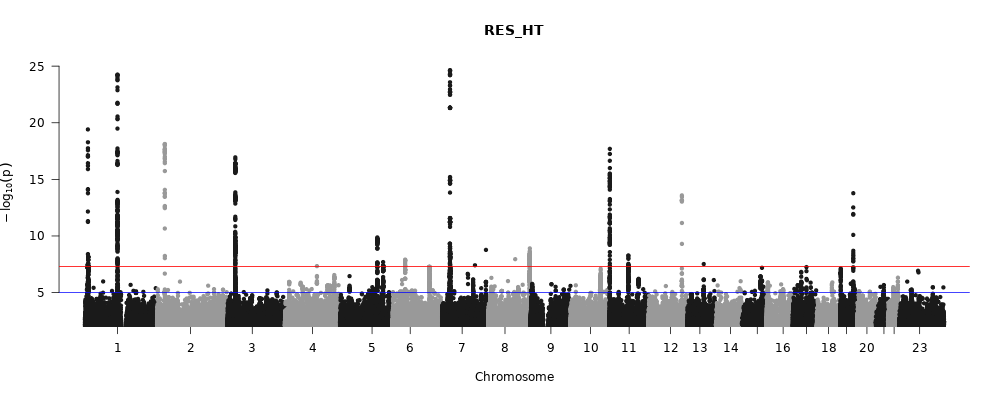

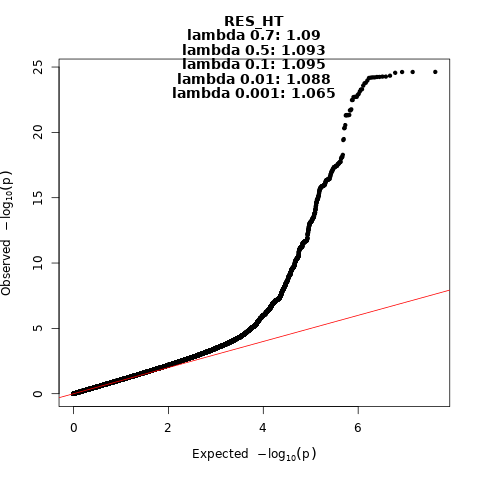

```r
fwrite(gwas_ORs_clean$RES_HT, "data/RES_HT_r12.csv", sep=";")
gwas_ORs_clean$RES_HT %>% my.kable()
```

| trait | cs_id | cs_size | variant | rsid | p | odds | p_ht | odds_ht | OR | most_severe | gene_most_severe |
| --- | --- | --- | --- | --- | --- | --- | --- | --- | --- | --- | --- |
| RES_HT | chr7:25702740-28702740_1 | 10 | 7:27202740:A:C | rs1859168 | 0 | 1.28 | 0.0e+00 | 1.14 | 1.13 | non_coding_transcript_exon_variant | HOTTIP |
| RES_HT | chr13:71747350-74747350_1 | 37 | 13:73247350:G:A | rs9573144 | 0 | 1.13 | 8.0e-02 | 1.01 | 1.11 | intergenic_variant | NA |
| RES_HT | chr1:111035403-114035403_1 | 7 | 1:112500200:T:C | rs12037987 | 0 | 1.21 | 0.0e+00 | 1.12 | 1.08 | intron_variant | WNT2B |
| RES_HT | chr7:25702740-28702740_2 | 11 | 7:27280700:T:C | rs4722681 | 0 | 1.15 | 0.0e+00 | 1.07 | 1.07 | intergenic_variant | NA |
| RES_HT | chr11:365986-3365986_1 | 3 | 11:1865986:T:C | rs612652 | 0 | 1.13 | 0.0e+00 | 1.06 | 1.07 | intron_variant | LSP1 |
| RES_HT | chr1:9236809-12236809_1 | 2 | 1:10736809:T:C | rs880315 | 0 | 1.14 | 0.0e+00 | 1.07 | 1.06 | intron_variant | CASZ1 |
| RES_HT | chr5:147015142-150015142_1 | 35 | 5:148515142:G:A | rs13154725 | 0 | 1.08 | 0.0e+00 | 1.03 | 1.05 | intron_variant | HTR4 |
| RES_HT | chr6:41802413-44802413_1 | 18 | 6:43302413:C:T | rs2270860 | 0 | 1.09 | 0.0e+00 | 1.05 | 1.04 | splice_region_variant | SLC22A7 |
| RES_HT | chr5:126979760-129979760_1 | 52 | 5:128479760:G:C | rs4385259 | 0 | 1.10 | 0.0e+00 | 1.06 | 1.04 | intron_variant | FBN2 |
| RES_HT | chr7:149493088-152493088_1 | 1 | 7:150993088:C:T | rs3918226 | 0 | 1.17 | 0.0e+00 | 1.17 | 1.00 | intron_variant | NOS3 |
| RES_HT | chr2:25188641-28188641_1 | 13 | 2:26688641:A:C | rs1275984 | 0 | 0.88 | 0.0e+00 | 0.92 | 0.96 | upstream_gene_variant | KCNK3 |
| RES_HT | chr8:141483465-144483465_1 | 121 | 8:142983465:C:T | rs61276460 | 0 | 0.92 | 4.0e-07 | 0.97 | 0.94 | intron_variant | LY6E-DT |
| RES_HT | chr12:113618502-116618502_1 | 7 | 12:115118502:T:G | rs35427 | 0 | 0.90 | 0.0e+00 | 0.95 | 0.94 | intergenic_variant | NA |
| RES_HT | chr1:111035403-114035403_2 | 71 | 1:112525170:A:G | rs3790611 | 0 | 0.89 | 0.0e+00 | 0.96 | 0.92 | 3_prime_UTR_variant | ST7L |
| RES_HT | chr3:25926806-28926806_1 | 37 | 3:27426806:C:G | rs7624512 | 0 | 0.89 | 0.0e+00 | 0.96 | 0.92 | intron_variant | SLC4A7 |
| RES_HT | chr19:43408684-46408684_1 | 2 | 19:44908684:T:C | rs429358 | 0 | 0.87 | 7.0e-03 | 0.98 | 0.89 | missense_variant | APOE |
| RES_HT | chr7:111630492-114630492_1 | 1 | 7:113130492:C:CA | NA | 0 | 0.86 | 3.7e-01 | 0.99 | 0.87 | intron_variant | AC073346.1 |
| RES_HT | chr8:91099599-94099599_1 | 1 | 8:92599599:G:GAGATAGATAGATAGATAGATAGAT | NA | 0 | 0.57 | 6.7e-01 | 0.98 | 0.58 | intron_variant | AC091096.1 |

### 3.3.2 NRCL_HT

- Maximum number of different antihypertensive medicine *classes* within 3 months window
- Only persons with diagnosed hypertension I9_HYPTENS and > 0 medicines

```r
 gwas_pheno %>% pull(NRCL_HT) %>% as.factor %>% summary()
```

```
##      1      2      3      4      5      6   NA's
##  15996  43043  54247  33092   6189    456 347325
```

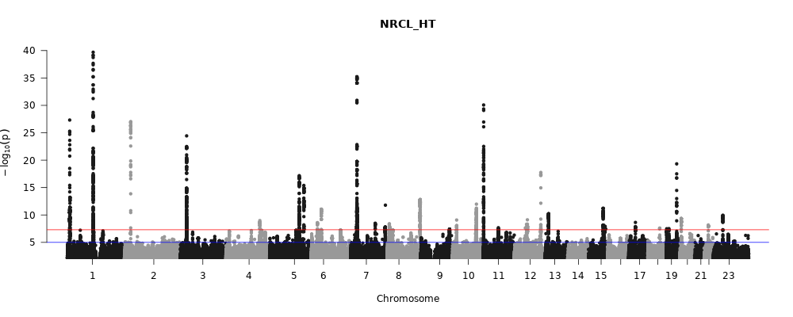

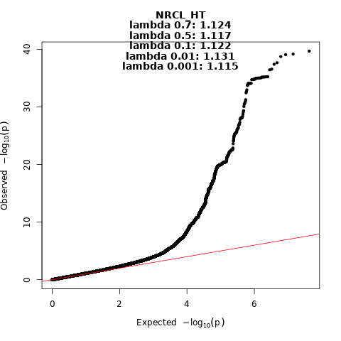

```r
fwrite(gwas_ORs_clean$NRCL_HT, "data/NRCL_HT_r12.csv", sep=";")
gwas_ORs_clean$NRCL_HT %>% my.kable()
```

| trait | cs_id | cs_size | variant | rsid | p | odds | p_ht | odds_ht | OR | most_severe | gene_most_severe |
| --- | --- | --- | --- | --- | --- | --- | --- | --- | --- | --- | --- |
| NRCL_HT | chr1:9236809-12236809_2 | 65 | 1:11836799:C:A | rs55892892 | 0.0e+00 | 0.95 | 0.0e+00 | 0.89 | 1.07 | intron_variant | CLCN6 |
| NRCL_HT | chr10:100964893-105516297_2 | 108 | 10:102868477:T:C | rs7098825 | 0.0e+00 | 0.97 | 0.0e+00 | 0.93 | 1.04 | non_coding_transcript_exon_variant | RF00026 |
| NRCL_HT | chr2:25188641-28188641_1 | 9 | 2:26688641:A:C | rs1275984 | 0.0e+00 | 0.96 | 0.0e+00 | 0.92 | 1.04 | upstream_gene_variant | KCNK3 |
| NRCL_HT | chr12:113618062-116618062_1 | 7 | 12:115118062:A:G | rs35429 | 0.0e+00 | 0.97 | 0.0e+00 | 0.95 | 1.01 | intergenic_variant | NA |
| NRCL_HT | chr7:149493088-152493088_2 | 69 | 7:150367061:C:T | rs11768108 | 0.0e+00 | 0.98 | 0.0e+00 | 0.97 | 1.01 | intron_variant | AC005586.1 |
| NRCL_HT | chr10:16725632-19725632_1 | 25 | 10:18225632:T:C | rs1779209 | 0.0e+00 | 0.98 | 0.0e+00 | 0.97 | 1.01 | intron_variant | CACNB2 |
| NRCL_HT | chr19:356555-3356555_1 | 28 | 19:1856555:C:G | NA | 0.0e+00 | 1.02 | 5.8e-03 | 1.01 | 1.01 | intron_variant | KLF16 |
| NRCL_HT | chr19:9685948-12685948_1 | 12 | 19:11185948:T:C | rs66536924 | 0.0e+00 | 0.98 | 6.0e-07 | 0.97 | 1.00 | intron_variant | KANK2 |
| NRCL_HT | chr9:124052115-127052115_1 | 67 | 9:125552115:T:C | rs521119 | 0.0e+00 | 1.02 | 2.4e-03 | 1.02 | 1.00 | intron_variant | MAPKAP1 |
| NRCL_HT | chr13:30119281-33119281_1 | 66 | 13:31619281:T:C | rs11616310 | 0.0e+00 | 1.02 | 2.6e-05 | 1.02 | 1.00 | intergenic_variant | NA |
| NRCL_HT | chr15:83637301-86637301_1 | 32 | 15:85137301:C:A | rs3743157 | 0.0e+00 | 1.03 | 8.2e-05 | 1.03 | 1.00 | intron_variant | PDE8A |
| NRCL_HT | chr12:51558093-54558093_2 | 9 | 12:53054953:G:T | NA | 4.5e-05 | 0.98 | 2.3e-03 | 0.98 | 1.00 | intron_variant | TNS2 |
| NRCL_HT | chr8:141428349-144428349_1 | 97 | 8:142928349:C:T | rs36176772 | 0.0e+00 | 0.97 | 1.0e-07 | 0.97 | 1.00 | intergenic_variant | NA |
| NRCL_HT | chr5:147015142-150015142_1 | 30 | 5:148515142:G:A | rs13154725 | 0.0e+00 | 1.03 | 0.0e+00 | 1.03 | 1.00 | intron_variant | HTR4 |
| NRCL_HT | chr17:27373104-30373104_1 | 21 | 17:28873104:C:T | rs9897840 | 0.0e+00 | 0.98 | 9.9e-05 | 0.98 | 1.00 | TF_binding_site_variant | NA |
| NRCL_HT | chr1:111001706-114001706_2 | 70 | 1:112541524:G:A | rs3790612 | 0.0e+00 | 0.96 | 0.0e+00 | 0.96 | 1.00 | intron_variant | ST7L |
| NRCL_HT | chr18:49773937-52773937_1 | 5 | 18:51273937:C:A | rs8090393 | 0.0e+00 | 1.02 | 9.0e-07 | 1.03 | 1.00 | intergenic_variant | NA |
| NRCL_HT | chr20:4864542-7864542_1 | 43 | 20:6364542:G:GT | NA | 0.0e+00 | 1.02 | 0.0e+00 | 1.03 | 0.99 | intergenic_variant | NA |
| NRCL_HT | chr23:42479788-45479788_1 | 18 | 23:43979788:T:G | rs5906346 | 0.0e+00 | 1.02 | 0.0e+00 | 1.03 | 0.99 | intergenic_variant | NA |
| NRCL_HT | chr11:64284647-67284647_1 | 70 | 11:65784647:G:A | rs948494 | 0.0e+00 | 1.02 | 1.0e-07 | 1.03 | 0.99 | upstream_gene_variant | OVOL1 |
| NRCL_HT | chr4:145846464-148846464_1 | 29 | 4:147506351:A:C | rs78049276 | 0.0e+00 | 1.03 | 0.0e+00 | 1.04 | 0.99 | non_coding_transcript_exon_variant | GTF2F2P1 |
| NRCL_HT | chr3:26021497-29021497_1 | 1 | 3:27521497:C:T | rs2643826 | 0.0e+00 | 1.04 | 0.0e+00 | 1.05 | 0.99 | upstream_gene_variant | AC137675.1 |
| NRCL_HT | chr15:87536144-90536144_1 | 49 | 15:89036144:A:G | rs75791528 | 0.0e+00 | 0.97 | 6.3e-02 | 0.99 | 0.99 | downstream_gene_variant | AC013565.2 |
| NRCL_HT | chr11:365986-3365986_1 | 3 | 11:1865986:T:C | rs612652 | 0.0e+00 | 1.04 | 0.0e+00 | 1.06 | 0.98 | intron_variant | LSP1 |
| NRCL_HT | chr15:79207660-82207660_1 | 25 | 15:80707660:A:C | rs923000 | 0.0e+00 | 1.03 | 0.0e+00 | 1.05 | 0.98 | intron_variant | ABHD17C |
| NRCL_HT | chr6:41794966-44794966_1 | 19 | 6:43294966:A:T | rs16896398 | 0.0e+00 | 1.03 | 0.0e+00 | 1.05 | 0.98 | upstream_gene_variant | SLC22A7 |
| NRCL_HT | chr7:25702740-28702740_2 | 10 | 7:27279420:G:A | rs28451436 | 0.0e+00 | 1.05 | 0.0e+00 | 1.07 | 0.98 | intergenic_variant | NA |
| NRCL_HT | chr22:27268637-30268637_1 | 22 | 22:28768637:T:A | rs200761661 | 0.0e+00 | 1.03 | 0.0e+00 | 1.05 | 0.98 | upstream_gene_variant | CCDC117 |
| NRCL_HT | chr5:127055665-130055665_1 | 44 | 5:128555665:T:C | rs4373322 | 0.0e+00 | 1.04 | 0.0e+00 | 1.06 | 0.98 | intron_variant | FBN2 |
| NRCL_HT | chr7:105269006-108269006_1 | 9 | 7:106769006:G:A | rs17398575 | 0.0e+00 | 1.02 | 0.0e+00 | 1.05 | 0.98 | intron_variant | AC004917.1 |
| NRCL_HT | chr12:55327025-58327025_1 | 25 | 12:56827025:G:GGT | NA | 0.0e+00 | 0.96 | 5.4e-02 | 0.98 | 0.97 | intron_variant | AC121758.1 |
| NRCL_HT | chr19:43408684-46408684_1 | 1 | 19:44908684:T:C | rs429358 | 0.0e+00 | 0.96 | 7.0e-03 | 0.98 | 0.97 | missense_variant | APOE |
| NRCL_HT | chr1:9236809-12236809_1 | 1 | 1:10736809:T:C | rs880315 | 0.0e+00 | 1.04 | 0.0e+00 | 1.07 | 0.97 | intron_variant | CASZ1 |
| NRCL_HT | chr12:46360570-49360570_1 | 3 | 12:47860570:T:A | rs117913411 | 0.0e+00 | 1.04 | 0.0e+00 | 1.08 | 0.97 | intron_variant | VDR |
| NRCL_HT | chr10:100964893-105516297_1 | 79 | 10:103939849:T:C | rs75263779 | 0.0e+00 | 1.06 | 0.0e+00 | 1.10 | 0.96 | intergenic_variant | NA |
| NRCL_HT | chr1:111001706-114001706_1 | 4 | 1:112501706:G:T | rs10776752 | 0.0e+00 | 1.07 | 0.0e+00 | 1.12 | 0.96 | intron_variant | WNT2B |
| NRCL_HT | chr7:25702740-28702740_1 | 18 | 7:27202740:A:C | rs1859168 | 0.0e+00 | 1.08 | 0.0e+00 | 1.14 | 0.96 | non_coding_transcript_exon_variant | HOTTIP |
| NRCL_HT | chr7:149493088-152493088_1 | 1 | 7:150993088:C:T | rs3918226 | 0.0e+00 | 1.05 | 0.0e+00 | 1.17 | 0.89 | intron_variant | NOS3 |
| NRCL_HT | chr12:51558093-54558093_1 | 5 | 12:53058093:C:T | rs151036307 | 0.0e+00 | 1.08 | 0.0e+00 | 1.26 | 0.85 | synonymous_variant | TNS2 |

### 3.3.3 NRCL_HT_INT

- Maximum number of different antihypertensive medicine *classes* within 3 months window
- Only persons with diagnosed hypertension I9_HYPTENS and > 0 medicines
- Inverse normal transformation for counts

```r
 gwas_pheno %>% pull(NRCL_HT_INT) %>% summary()
```

```
##    Min. 1st Qu.  Median    Mean 3rd Qu.    Max.    NA's
##    -1.6    -0.7     0.2     0.0     1.0     3.0  347325
```

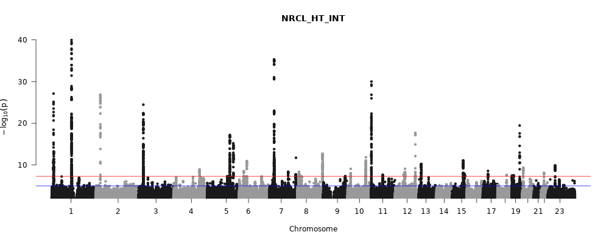

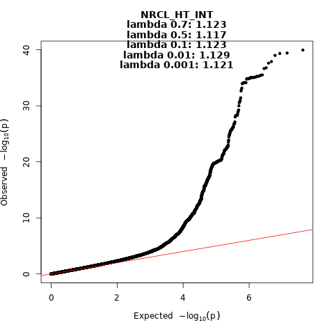

```r
fwrite(gwas_ORs_clean$NRCL_HT_INT, "data/NRCL_HT_INT_r12.csv", sep=";")
gwas_ORs_clean$NRCL_HT_INT  %>% my.kable()
```

| trait | cs_id | cs_size | variant | rsid | p | odds | p_ht | odds_ht | OR | most_severe | gene_most_severe |
| --- | --- | --- | --- | --- | --- | --- | --- | --- | --- | --- | --- |
| NRCL_HT_INT | chr1:9236809-12236809_2 | 65 | 1:11836799:C:A | rs55892892 | 0.0e+00 | 0.96 | 0.0e+00 | 0.89 | 1.08 | intron_variant | CLCN6 |
| NRCL_HT_INT | chr10:100964893-105516297_2 | 109 | 10:102868477:T:C | rs7098825 | 0.0e+00 | 0.97 | 0.0e+00 | 0.93 | 1.05 | non_coding_transcript_exon_variant | RF00026 |
| NRCL_HT_INT | chr2:25188641-28188641_1 | 9 | 2:26688641:A:C | rs1275984 | 0.0e+00 | 0.97 | 0.0e+00 | 0.92 | 1.04 | upstream_gene_variant | KCNK3 |
| NRCL_HT_INT | chr12:113618062-116618062_1 | 7 | 12:115118062:A:G | rs35429 | 0.0e+00 | 0.97 | 0.0e+00 | 0.95 | 1.02 | intergenic_variant | NA |
| NRCL_HT_INT | chr7:149493088-152493088_2 | 69 | 7:150367061:C:T | rs11768108 | 0.0e+00 | 0.98 | 0.0e+00 | 0.97 | 1.01 | intron_variant | AC005586.1 |
| NRCL_HT_INT | chr10:16725632-19725632_1 | 25 | 10:18225632:T:C | rs1779209 | 0.0e+00 | 0.98 | 0.0e+00 | 0.97 | 1.01 | intron_variant | CACNB2 |
| NRCL_HT_INT | chr5:113559877-116559877_1 | 101 | 5:115059877:A:C | rs186934271 | 0.0e+00 | 0.98 | 1.0e-07 | 0.97 | 1.01 | intergenic_variant | NA |
| NRCL_HT_INT | chr19:9685948-12685948_1 | 12 | 19:11185948:T:C | rs66536924 | 0.0e+00 | 0.98 | 6.0e-07 | 0.97 | 1.01 | intron_variant | KANK2 |
| NRCL_HT_INT | chr19:356555-3356555_1 | 28 | 19:1856555:C:G | NA | 0.0e+00 | 1.02 | 5.8e-03 | 1.01 | 1.00 | intron_variant | KLF16 |
| NRCL_HT_INT | chr8:141428349-144428349_1 | 96 | 8:142928349:C:T | rs36176772 | 0.0e+00 | 0.98 | 1.0e-07 | 0.97 | 1.00 | intergenic_variant | NA |
| NRCL_HT_INT | chr9:124052115-127052115_1 | 68 | 9:125552115:T:C | rs521119 | 0.0e+00 | 1.02 | 2.4e-03 | 1.02 | 1.00 | intron_variant | MAPKAP1 |
| NRCL_HT_INT | chr1:111001706-114001706_2 | 70 | 1:112541524:G:A | rs3790612 | 0.0e+00 | 0.96 | 0.0e+00 | 0.96 | 1.00 | intron_variant | ST7L |
| NRCL_HT_INT | chr12:51558093-54558093_2 | 9 | 12:53054953:G:T | NA | 4.1e-05 | 0.99 | 2.3e-03 | 0.98 | 1.00 | intron_variant | TNS2 |
| NRCL_HT_INT | chr17:27373104-30373104_1 | 21 | 17:28873104:C:T | rs9897840 | 0.0e+00 | 0.98 | 9.9e-05 | 0.98 | 1.00 | TF_binding_site_variant | NA |
| NRCL_HT_INT | chr13:30119281-33119281_1 | 65 | 13:31619281:T:C | rs11616310 | 0.0e+00 | 1.02 | 2.6e-05 | 1.02 | 1.00 | intergenic_variant | NA |
| NRCL_HT_INT | chr15:83637301-86637301_1 | 34 | 15:85137301:C:A | rs3743157 | 0.0e+00 | 1.03 | 8.2e-05 | 1.03 | 1.00 | intron_variant | PDE8A |
| NRCL_HT_INT | chr5:147015142-150015142_1 | 30 | 5:148515142:G:A | rs13154725 | 0.0e+00 | 1.03 | 0.0e+00 | 1.03 | 0.99 | intron_variant | HTR4 |
| NRCL_HT_INT | chr18:49773937-52773937_1 | 5 | 18:51273937:C:A | rs8090393 | 0.0e+00 | 1.02 | 9.0e-07 | 1.03 | 0.99 | intergenic_variant | NA |
| NRCL_HT_INT | chr23:42479788-45479788_1 | 18 | 23:43979788:T:G | rs5906346 | 0.0e+00 | 1.02 | 0.0e+00 | 1.03 | 0.99 | intergenic_variant | NA |
| NRCL_HT_INT | chr20:4864542-7864542_1 | 43 | 20:6364542:G:GT | NA | 0.0e+00 | 1.02 | 0.0e+00 | 1.03 | 0.99 | intergenic_variant | NA |
| NRCL_HT_INT | chr11:64284647-67284647_1 | 70 | 11:65784647:G:A | rs948494 | 0.0e+00 | 1.02 | 1.0e-07 | 1.03 | 0.99 | upstream_gene_variant | OVOL1 |
| NRCL_HT_INT | chr15:87536144-90536144_1 | 49 | 15:89036144:A:G | rs75791528 | 0.0e+00 | 0.98 | 6.3e-02 | 0.99 | 0.99 | downstream_gene_variant | AC013565.2 |
| NRCL_HT_INT | chr4:145846464-148846464_1 | 28 | 4:147506351:A:C | rs78049276 | 0.0e+00 | 1.03 | 0.0e+00 | 1.04 | 0.99 | non_coding_transcript_exon_variant | GTF2F2P1 |
| NRCL_HT_INT | chr3:26021497-29021497_1 | 1 | 3:27521497:C:T | rs2643826 | 0.0e+00 | 1.03 | 0.0e+00 | 1.05 | 0.98 | upstream_gene_variant | AC137675.1 |
| NRCL_HT_INT | chr12:55327025-58327025_1 | 25 | 12:56827025:G:GGT | NA | 0.0e+00 | 0.96 | 5.4e-02 | 0.98 | 0.98 | intron_variant | AC121758.1 |
| NRCL_HT_INT | chr11:365986-3365986_1 | 3 | 11:1865986:T:C | rs612652 | 0.0e+00 | 1.04 | 0.0e+00 | 1.06 | 0.98 | intron_variant | LSP1 |
| NRCL_HT_INT | chr19:43408684-46408684_1 | 1 | 19:44908684:T:C | rs429358 | 0.0e+00 | 0.96 | 7.0e-03 | 0.98 | 0.98 | missense_variant | APOE |
| NRCL_HT_INT | chr15:79207660-82207660_1 | 25 | 15:80707660:A:C | rs923000 | 0.0e+00 | 1.02 | 0.0e+00 | 1.05 | 0.98 | intron_variant | ABHD17C |
| NRCL_HT_INT | chr6:41794966-44794966_1 | 19 | 6:43294966:A:T | rs16896398 | 0.0e+00 | 1.02 | 0.0e+00 | 1.05 | 0.98 | upstream_gene_variant | SLC22A7 |
| NRCL_HT_INT | chr22:27268637-30268637_1 | 22 | 22:28768637:T:A | rs200761661 | 0.0e+00 | 1.02 | 0.0e+00 | 1.05 | 0.97 | upstream_gene_variant | CCDC117 |
| NRCL_HT_INT | chr7:105269006-108269006_1 | 9 | 7:106769006:G:A | rs17398575 | 0.0e+00 | 1.02 | 0.0e+00 | 1.05 | 0.97 | intron_variant | AC004917.1 |
| NRCL_HT_INT | chr5:127055665-130055665_1 | 43 | 5:128555665:T:C | rs4373322 | 0.0e+00 | 1.03 | 0.0e+00 | 1.06 | 0.97 | intron_variant | FBN2 |
| NRCL_HT_INT | chr7:25702740-28702740_2 | 10 | 7:27279420:G:A | rs28451436 | 0.0e+00 | 1.04 | 0.0e+00 | 1.07 | 0.97 | intergenic_variant | NA |
| NRCL_HT_INT | chr1:9236809-12236809_1 | 1 | 1:10736809:T:C | rs880315 | 0.0e+00 | 1.04 | 0.0e+00 | 1.07 | 0.96 | intron_variant | CASZ1 |
| NRCL_HT_INT | chr12:46360570-49360570_1 | 2 | 12:47860570:T:A | rs117913411 | 0.0e+00 | 1.04 | 0.0e+00 | 1.08 | 0.96 | intron_variant | VDR |
| NRCL_HT_INT | chr10:100964893-105516297_1 | 80 | 10:103939849:T:C | rs75263779 | 0.0e+00 | 1.05 | 0.0e+00 | 1.10 | 0.96 | intergenic_variant | NA |
| NRCL_HT_INT | chr1:111001706-114001706_1 | 4 | 1:112501706:G:T | rs10776752 | 0.0e+00 | 1.06 | 0.0e+00 | 1.12 | 0.95 | intron_variant | WNT2B |
| NRCL_HT_INT | chr7:25702740-28702740_1 | 18 | 7:27202740:A:C | rs1859168 | 0.0e+00 | 1.07 | 0.0e+00 | 1.14 | 0.95 | non_coding_transcript_exon_variant | HOTTIP |
| NRCL_HT_INT | chr7:149493088-152493088_1 | 1 | 7:150993088:C:T | rs3918226 | 0.0e+00 | 1.04 | 0.0e+00 | 1.17 | 0.89 | intron_variant | NOS3 |
| NRCL_HT_INT | chr12:51558093-54558093_1 | 5 | 12:53058093:C:T | rs151036307 | 0.0e+00 | 1.07 | 0.0e+00 | 1.26 | 0.85 | synonymous_variant | TNS2 |

### 3.3.4 RES_HT0

- Cases: >= 4 drug classes within 3 months time window *and* I9_HYPTENS.
- Controls: 0 drug purchases and no I9_HYPTENS. (Healthy individuals)

```r
 gwas_pheno %>% pull(RES_HT0) %>% as.factor %>% summary()
```

```
##      0      1   NA's
## 185547  39737 275064
```

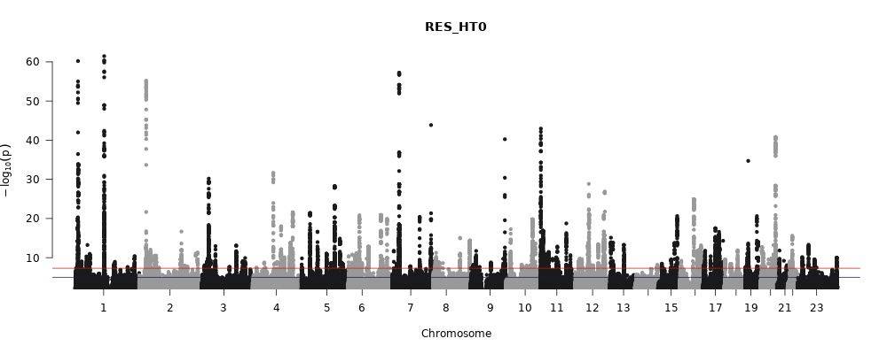

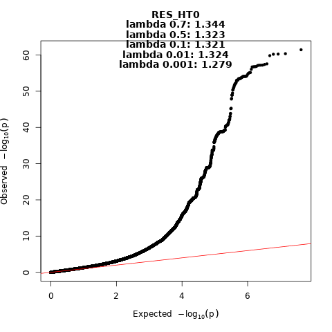

```r
fwrite(gwas_ORs_clean$RES_HT0, "data/RES_HT0_r12.csv", sep=";")
gwas_ORs_clean$RES_HT0 %>% my.kable()
```

| trait | cs_id | cs_size | variant | rsid | p | odds | p_ht | odds_ht | OR | most_severe | gene_most_severe |
| --- | --- | --- | --- | --- | --- | --- | --- | --- | --- | --- | --- |
| RES_HT0 | chr11:8730294-14022758_2 | 7 | 11:12522758:G:T | rs576208890 | 0.0e+00 | 1.39 | 3.1e-05 | 1.13 | 1.23 | intron_variant | PARVA |
| RES_HT0 | chr10:99825287-106624496_3 | 7 | 10:105045593:A:T | rs540369678 | 0.0e+00 | 1.54 | 0.0e+00 | 1.26 | 1.22 | intron_variant | SORCS3 |
| RES_HT0 | chr12:46360570-54558093_1 | 1 | 12:53058093:C:T | rs151036307 | 0.0e+00 | 1.49 | 0.0e+00 | 1.26 | 1.18 | synonymous_variant | TNS2 |
| RES_HT0 | chr19:9916089-14507610_3 | 3 | 19:11281314:C:T | rs150205856 | 0.0e+00 | 1.40 | 0.0e+00 | 1.19 | 1.18 | intergenic_variant | NA |
| RES_HT0 | chr7:25705482-28705482_1 | 9 | 7:27205482:G:T | rs929250 | 0.0e+00 | 1.33 | 0.0e+00 | 1.14 | 1.17 | non_coding_transcript_exon_variant | HOTTIP |
| RES_HT0 | chr7:15445722-18445722_1 | 5 | 7:16945722:A:C | rs184169070 | 0.0e+00 | 1.20 | 2.8e-03 | 1.05 | 1.14 | intron_variant | AHR |
| RES_HT0 | chr5:58682328-64739607_1 | 2 | 5:61698068:T:G | rs186043316 | 0.0e+00 | 1.40 | 0.0e+00 | 1.23 | 1.14 | non_coding_transcript_exon_variant | AC026746.1 |
| RES_HT0 | chr13:70418596-73418596_2 | 25 | 13:73252270:A:C | rs76854112 | 0.0e+00 | 1.20 | 2.0e-06 | 1.07 | 1.13 | intergenic_variant | NA |
| RES_HT0 | chr10:99825287-106624496_2 | 17 | 10:103939849:T:C | rs75263779 | 0.0e+00 | 1.24 | 0.0e+00 | 1.10 | 1.13 | intergenic_variant | NA |
| RES_HT0 | chr23:17925105-20925105_1 | 20 | 23:19425105:G:A | rs757954972 | 0.0e+00 | 1.25 | 0.0e+00 | 1.11 | 1.12 | intron_variant | MAP3K15 |
| RES_HT0 | chr7:149493088-152493088_1 | 1 | 7:150993088:C:T | rs3918226 | 0.0e+00 | 1.32 | 0.0e+00 | 1.17 | 1.12 | intron_variant | NOS3 |
| RES_HT0 | chr1:111001706-115538060_1 | 3 | 1:112501706:G:T | rs10776752 | 0.0e+00 | 1.25 | 0.0e+00 | 1.12 | 1.12 | intron_variant | WNT2B |
| RES_HT0 | chr7:4849971-7849971_1 | 4 | 7:6349971:C:G | rs138737429 | 0.0e+00 | 1.18 | 1.0e-06 | 1.06 | 1.12 | upstream_gene_variant | FAM220A |
| RES_HT0 | chr20:29902955-32902955_1 | 3 | 20:31402955:C:T | rs76819384 | 0.0e+00 | 1.23 | 0.0e+00 | 1.11 | 1.11 | downstream_gene_variant | DEFB121 |
| RES_HT0 | chr6:69891227-72891227_1 | 1 | 6:71391227:G:T | rs192807858 | 0.0e+00 | 1.22 | 0.0e+00 | 1.10 | 1.10 | intron_variant | LINC00472 |
| RES_HT0 | chr1:9236809-12236809_1 | 1 | 1:10736809:T:C | rs880315 | 0.0e+00 | 1.18 | 0.0e+00 | 1.07 | 1.10 | intron_variant | CASZ1 |
| RES_HT0 | chr7:25705482-28705482_2 | 11 | 7:27310988:A:G | rs17502580 | 0.0e+00 | 1.17 | 0.0e+00 | 1.07 | 1.09 | intergenic_variant | NA |
| RES_HT0 | chr11:365986-6176032_1 | 2 | 11:1865986:T:C | rs612652 | 0.0e+00 | 1.15 | 0.0e+00 | 1.06 | 1.09 | intron_variant | LSP1 |
| RES_HT0 | chr16:65404920-71041335_1 | 80 | 16:66904920:G:C | rs8062688 | 0.0e+00 | 1.15 | 0.0e+00 | 1.06 | 1.09 | downstream_gene_variant | CDH16 |
| RES_HT0 | chr6:13864157-16864157_1 | 2 | 6:15364157:T:TCAGG | NA | 0.0e+00 | 1.13 | 1.0e-07 | 1.05 | 1.08 | intron_variant | JARID2 |
| RES_HT0 | chr17:42819528-50612937_1 | 6 | 17:47212712:T:G | rs78033733 | 0.0e+00 | 1.16 | 0.0e+00 | 1.08 | 1.08 | intron_variant | MYL4 |
| RES_HT0 | chr4:145971576-148971576_1 | 21 | 4:147471576:C:T | rs6823438 | 0.0e+00 | 1.12 | 0.0e+00 | 1.05 | 1.07 | intergenic_variant | NA |
| RES_HT0 | chr10:112521768-115521768_2 | 11 | 10:113961846:G:A | rs74157558 | 2.0e-07 | 1.13 | 1.8e-06 | 1.06 | 1.07 | intergenic_variant | NA |
| RES_HT0 | chr9:125394544-128394544_1 | 21 | 9:126894544:G:C | rs74767468 | 0.0e+00 | 1.14 | 0.0e+00 | 1.07 | 1.07 | regulatory_region_variant | NA |
| RES_HT0 | chr20:57640492-60640492_1 | 14 | 20:59140492:T:TATTTA | rs113817166 | 0.0e+00 | 1.20 | 0.0e+00 | 1.12 | 1.07 | intron_variant | ZNF831 |
| RES_HT0 | chr7:25705482-28705482_3 | 28 | 7:27134697:G:A | rs1548497 | 0.0e+00 | 1.14 | 0.0e+00 | 1.07 | 1.07 | intron_variant | HOXA3 |
| RES_HT0 | chr1:46098380-51068310_1 | 1 | 1:47598380:A:C | rs11211570 | 0.0e+00 | 1.13 | 0.0e+00 | 1.05 | 1.07 | intergenic_variant | NA |
| RES_HT0 | chr5:127037912-130037912_1 | 12 | 5:128537912:T:C | rs7732639 | 0.0e+00 | 1.13 | 0.0e+00 | 1.06 | 1.07 | 5_prime_UTR_variant | FBN2 |
| RES_HT0 | chr2:217494449-220494449_1 | 3 | 2:218994449:G:A | rs113414093 | 0.0e+00 | 1.13 | 0.0e+00 | 1.07 | 1.06 | upstream_gene_variant | CRYBA2 |
| RES_HT0 | chr18:49137671-52137671_1 | 12 | 18:50637671:G:A | rs35490129 | 0.0e+00 | 1.09 | 2.6e-06 | 1.03 | 1.06 | intron_variant | MAPK4 |

[output cut: 176 more lines]

### 3.3.5 I9_HYPTENS

Self run as a control. Should correspond: https://results.finngen.fi/pheno/I9_HYPTENS

```r
 gwas_pheno %>% pull(HYPTENS) %>% as.factor %>% summary()
```

```
##      0      1   NA's
## 345634 154630     84
```

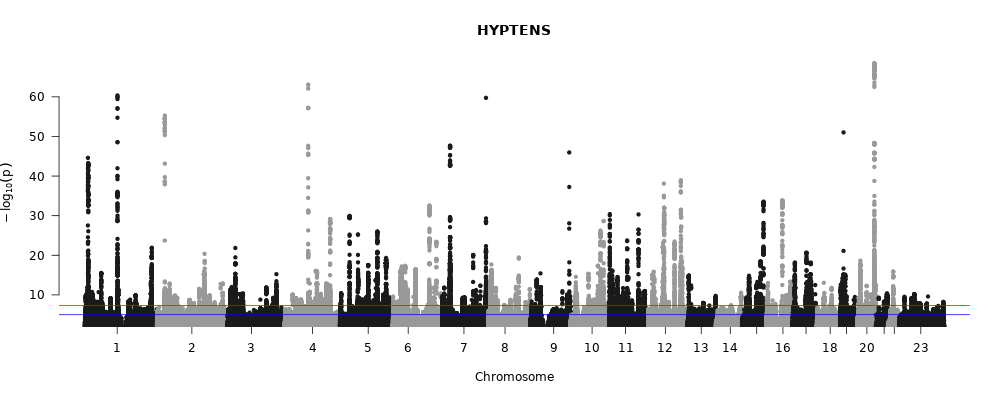

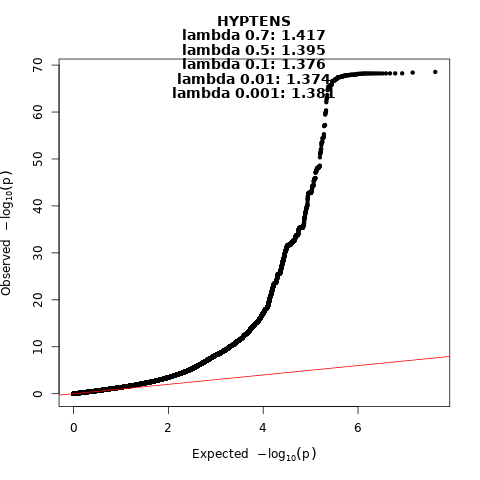

# 4 Replication at UKBB

We performed replication study at UKBB RAP

## 4.1 Phenotypes

**Variables**

- resht_fg:
  - Number of medication classes >= 4
  - Hypertension
- resht_ukb (official definition):
  - Number of medication classes >= 3
  - Systolic BP >= or diastolic BP >= 90
  - Hypertension
- resht_both
  - resht_fg or resht_ukb

Control: Hypertension diagnosis and one class of hypertensive medication.

Criteria was evaluated **at baseline**, not by sliding window as in FinnGen. As a results we got much smaller number of cases.

**Phenotype files created at UKBB RAP**

```
create_ukbb_pheno_resht.Rmd
```

## 4.2 Regenie

We used raw chip data (variable 22418) for regenie step 1 and imputed data from Genomics england (variable 21008) for regenie step 2.

**Liftover**

Chip data was in GRCh337 while imputed data was in GRCh38. Liftover was needed prior to Regenie run.

```
run_liftover.ipynb
```

**Regenie runs at UKBB RAP**

This includes preprocessing of data, regenie run and post processing.

```
run_regenie_resht.ipynb
```

## 4.3 UKBB results and replication

We selected significant variants from FinnGen SUSIE finemapping and considered replication successful, if P value after Bonnferroni correction was < 0.05 and beta had same sign in both datasets using number of singificant variants as n. Also alleles and allele frequences were inspected as a sanity check. This was run at *local computer*.

```bash
Rscript check_signif_snip.R
```

Result figures and tables were uploaded.

Column names:

- rsid:most_severe: FinnGen SUSIE results
- IS_P: Is Bonferroni adjusted P value for UKBB < 0.05
- IS_SIGN: Is sign of beta same for FinnGen and UKBB
- pval, beta, af_alt: FinnGen values
- P, BETA, A1FREQ: UKBB values

### 4.3.1 resht_ukb

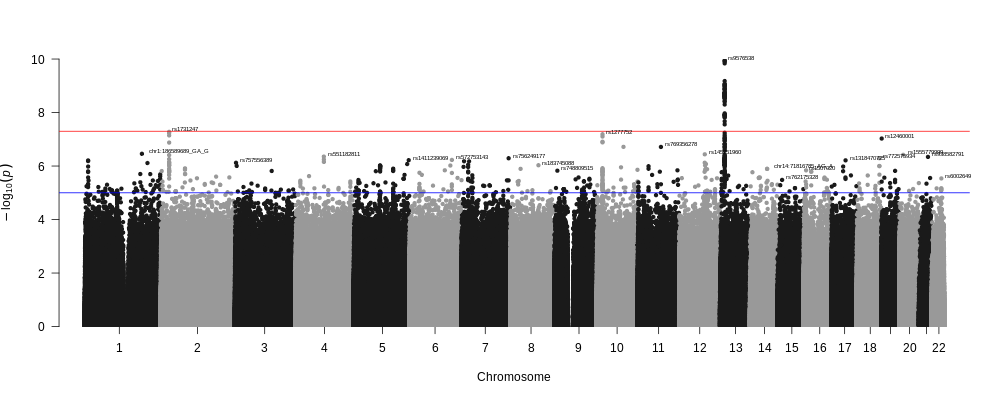

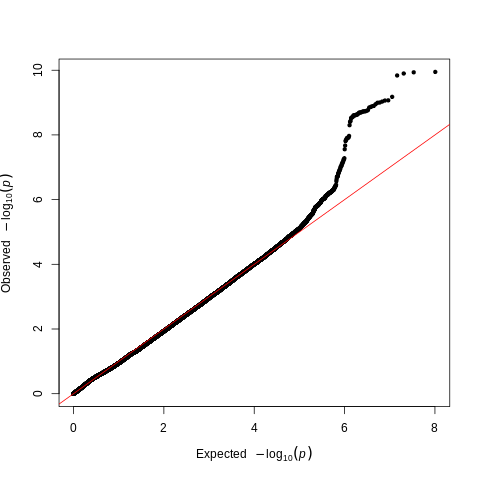

```r
fread("data/regenie_ukbb/replic_ukbvar_all.csv") %>% my.kable()
```

| rsid | variant | gene_most_severe | most_severe | IS_P | IS_SIGN | pval | P | beta | BETA | af_alt | A1FREQ |
| --- | --- | --- | --- | --- | --- | --- | --- | --- | --- | --- | --- |
| rs880315 | 1:10736809:T:C | CASZ1 | intron_variant | TRUE | TRUE | 0 | 0.0000007 | 0.1286980 | 0.1106820 | 0.4289090 | 0.3497970 |
| rs12037987 | 1:112500200:T:C | WNT2B | intron_variant | TRUE | TRUE | 0 | 0.0001439 | 0.1885920 | 0.1474510 | 0.1817380 | 0.0776172 |
| rs3790611 | 1:112525170:A:G | ST7L | 3_prime_UTR_variant | FALSE | TRUE | 0 | 0.0813804 | -0.1212400 | -0.0428985 | 0.2287410 | 0.2540850 |
| rs1275984 | 2:26688641:A:C | KCNK3 | upstream_gene_variant | NA | NA | 0 | NA | -0.1232670 | NA | 0.5327440 | NA |
| rs7624512 | 3:27426806:C:G | SLC4A7 | intron_variant | TRUE | TRUE | 0 | 0.0013327 | -0.1217630 | -0.0719267 | 0.3756890 | 0.3556600 |
| rs4385259 | 5:128479760:G:C | FBN2 | intron_variant | FALSE | TRUE | 0 | 0.0113580 | 0.0929314 | 0.0547112 | 0.3562410 | 0.4252550 |
| rs13154725 | 5:148515142:G:A | HTR4 | intron_variant | FALSE | TRUE | 0 | 0.3496786 | 0.0790377 | 0.0202408 | 0.3976410 | 0.4276210 |
| rs2270860 | 6:43302413:C:T | SLC22A7 | splice_region_variant | FALSE | TRUE | 0 | 0.0458934 | 0.0855846 | 0.0462211 | 0.3066900 | 0.2977840 |
| rs1859168 | 7:27202740:A:C | HOTTIP | non_coding_transcript_exon_variant | TRUE | TRUE | 0 | 0.0017198 | 0.2497700 | 0.1359300 | 0.9129630 | 0.9319000 |
| rs4722681 | 7:27280700:T:C |  | intergenic_variant | TRUE | TRUE | 0 | 0.0000422 | 0.1393390 | 0.1387600 | 0.1437800 | 0.1050930 |
| rs57239204 | 7:113130492:C:CA | AC073346.1 | intron_variant | NA | NA | 0 | NA | -0.1525640 | NA | 0.0656184 | NA |
| rs3918226 | 7:150993088:C:T | NOS3 | intron_variant | FALSE | TRUE | 0 | 0.3210392 | 0.1589050 | 0.0374456 | 0.0763068 | 0.0899605 |
| rs59122069 | 8:92599599:G:GAGATAGATAGATAGATAGATAGAT | AC091096.1 | intron_variant | FALSE | FALSE | 0 | 0.7820130 | -0.5682390 | 0.1291670 | 0.0059113 | 0.0007558 |
| rs61276460 | 8:142983465:C:T | LY6E-DT | intron_variant | FALSE | TRUE | 0 | 0.0585531 | -0.0844013 | -0.0414887 | 0.4703760 | 0.3915200 |
| rs612652 | 11:1865986:T:C | LSP1 | intron_variant | TRUE | TRUE | 0 | 0.0002049 | 0.1228170 | 0.0806974 | 0.5859100 | 0.5926310 |
| rs35427 | 12:115118502:T:G |  | intergenic_variant | FALSE | TRUE | 0 | 0.0200683 | -0.1104970 | -0.0513407 | 0.3556520 | 0.3753110 |
| rs9573144 | 13:73247350:G:A |  | intergenic_variant | FALSE | TRUE | 0 | 0.2583955 | 0.1187560 | 0.0405058 | 0.1215770 | 0.0995943 |
| rs429358 | 19:44908684:T:C | APOE | missense_variant | FALSE | TRUE | 0 | 0.5469870 | -0.1391940 | -0.0179074 | 0.1711720 | 0.1533970 |

### 4.3.2 resht_fg

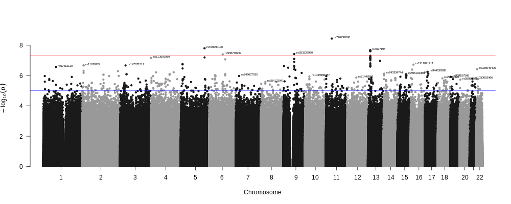

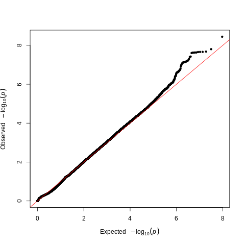

```r
fread("data/regenie_ukbb/replic_fgvar_all.csv") %>% my.kable()
```

| rsid | variant | gene_most_severe | most_severe | IS_P | IS_SIGN | pval | P | beta | BETA | af_alt | A1FREQ |
| --- | --- | --- | --- | --- | --- | --- | --- | --- | --- | --- | --- |
| rs880315 | 1:10736809:T:C | CASZ1 | intron_variant | TRUE | TRUE | 0 | 0.0000782 | 0.1286980 | 0.1590410 | 0.4289090 | 0.3479750 |
| rs12037987 | 1:112500200:T:C | WNT2B | intron_variant | FALSE | TRUE | 0 | 0.0525339 | 0.1885920 | 0.1414620 | 0.1817380 | 0.0765347 |
| rs3790611 | 1:112525170:A:G | ST7L | 3_prime_UTR_variant | FALSE | TRUE | 0 | 0.1110596 | -0.1212400 | -0.0712118 | 0.2287410 | 0.2546690 |
| rs1275984 | 2:26688641:A:C | KCNK3 | upstream_gene_variant | TRUE | TRUE | 0 | 0.0001044 | -0.1232670 | -0.1525480 | 0.5327440 | 0.6057800 |
| rs7624512 | 3:27426806:C:G | SLC4A7 | intron_variant | FALSE | TRUE | 0 | 0.3006810 | -0.1217630 | -0.0421135 | 0.3756890 | 0.3578260 |
| rs4385259 | 5:128479760:G:C | FBN2 | intron_variant | FALSE | TRUE | 0 | 0.0078665 | 0.0929314 | 0.1046280 | 0.3562410 | 0.4242190 |
| rs13154725 | 5:148515142:G:A | HTR4 | intron_variant | FALSE | TRUE | 0 | 0.0685772 | 0.0790377 | 0.0716668 | 0.3976410 | 0.4276030 |
| rs2270860 | 6:43302413:C:T | SLC22A7 | splice_region_variant | FALSE | FALSE | 0 | 0.7667592 | 0.0855846 | -0.0125176 | 0.3066900 | 0.2961790 |
| rs1859168 | 7:27202740:A:C | HOTTIP | non_coding_transcript_exon_variant | FALSE | TRUE | 0 | 0.1295028 | 0.2497700 | 0.1164020 | 0.9129630 | 0.9310410 |
| rs4722681 | 7:27280700:T:C |  | intergenic_variant | TRUE | TRUE | 0 | 0.0000435 | 0.1393390 | 0.2482560 | 0.1437800 | 0.1041030 |
| rs57239204 | 7:113130492:C:CA | AC073346.1 | intron_variant | NA | NA | 0 | NA | -0.1525640 | NA | 0.0656184 | NA |
| rs3918226 | 7:150993088:C:T | NOS3 | intron_variant | FALSE | TRUE | 0 | 0.1163697 | 0.1589050 | 0.1076200 | 0.0763068 | 0.0901806 |
| rs59122069 | 8:92599599:G:GAGATAGATAGATAGATAGATAGAT | AC091096.1 | intron_variant | FALSE | FALSE | 0 | 0.3380913 | -0.5682390 | 0.7701800 | 0.0059113 | 0.0007723 |
| rs61276460 | 8:142983465:C:T | LY6E-DT | intron_variant | FALSE | TRUE | 0 | 0.3771542 | -0.0844013 | -0.0352355 | 0.4703760 | 0.3924640 |
| rs612652 | 11:1865986:T:C | LSP1 | intron_variant | TRUE | TRUE | 0 | 0.0000171 | 0.1228170 | 0.1713530 | 0.5859100 | 0.5916220 |
| rs35427 | 12:115118502:T:G |  | intergenic_variant | FALSE | TRUE | 0 | 0.0156686 | -0.1104970 | -0.0975913 | 0.3556520 | 0.3761470 |
| rs9573144 | 13:73247350:G:A |  | intergenic_variant | FALSE | FALSE | 0 | 0.3795369 | 0.1187560 | -0.0579691 | 0.1215770 | 0.0987524 |
| rs429358 | 19:44908684:T:C | APOE | missense_variant | FALSE | TRUE | 0 | 0.0972926 | -0.1391940 | -0.0894026 | 0.1711720 | 0.1533930 |

### 4.3.3 resht_both

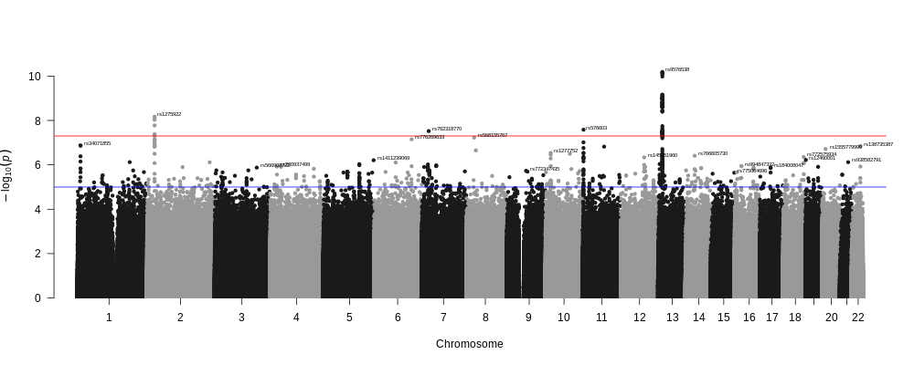

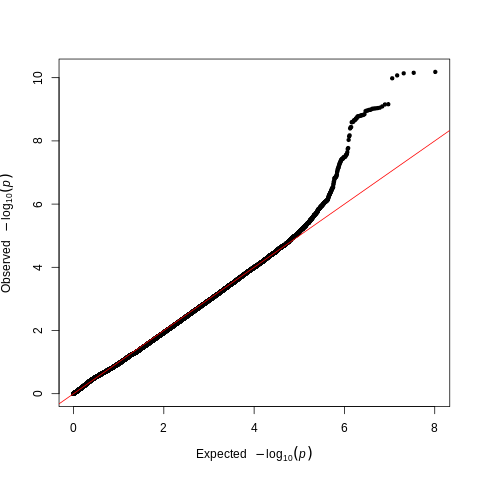

```r
fread("data/regenie_ukbb/replic_bothvar_all.csv") %>% my.kable()
```

| rsid | variant | gene_most_severe | most_severe | IS_P | IS_SIGN | pval | P | beta | BETA | af_alt | A1FREQ |
| --- | --- | --- | --- | --- | --- | --- | --- | --- | --- | --- | --- |
| rs880315 | 1:10736809:T:C | CASZ1 | intron_variant | TRUE | TRUE | 0 | 0.0000001 | 0.1286980 | 0.1124400 | 0.4289090 | 0.3501750 |
| rs12037987 | 1:112500200:T:C | WNT2B | intron_variant | TRUE | TRUE | 0 | 0.0001169 | 0.1885920 | 0.1436320 | 0.1817380 | 0.0777556 |
| rs3790611 | 1:112525170:A:G | ST7L | 3_prime_UTR_variant | FALSE | TRUE | 0 | 0.0495907 | -0.1212400 | -0.0466092 | 0.2287410 | 0.2539300 |
| rs1275984 | 2:26688641:A:C | KCNK3 | upstream_gene_variant | TRUE | TRUE | 0 | 0.0000001 | -0.1232670 | -0.1093710 | 0.5327440 | 0.6031660 |
| rs7624512 | 3:27426806:C:G | SLC4A7 | intron_variant | TRUE | TRUE | 0 | 0.0027254 | -0.1217630 | -0.0644984 | 0.3756890 | 0.3556930 |
| rs4385259 | 5:128479760:G:C | FBN2 | intron_variant | FALSE | TRUE | 0 | 0.0056718 | 0.0929314 | 0.0574459 | 0.3562410 | 0.4255690 |
| rs13154725 | 5:148515142:G:A | HTR4 | intron_variant | FALSE | TRUE | 0 | 0.2540546 | 0.0790377 | 0.0236702 | 0.3976410 | 0.4279270 |
| rs2270860 | 6:43302413:C:T | SLC22A7 | splice_region_variant | FALSE | TRUE | 0 | 0.0289668 | 0.0855846 | 0.0485340 | 0.3066900 | 0.2979030 |
| rs1859168 | 7:27202740:A:C | HOTTIP | non_coding_transcript_exon_variant | FALSE | TRUE | 0 | 0.0082773 | 0.2497700 | 0.1093540 | 0.9129630 | 0.9317820 |
| rs4722681 | 7:27280700:T:C |  | intergenic_variant | TRUE | TRUE | 0 | 0.0000022 | 0.1393390 | 0.1539100 | 0.1437800 | 0.1054350 |
| rs57239204 | 7:113130492:C:CA | AC073346.1 | intron_variant | NA | NA | 0 | NA | -0.1525640 | NA | 0.0656184 | NA |
| rs3918226 | 7:150993088:C:T | NOS3 | intron_variant | FALSE | TRUE | 0 | 0.2225743 | 0.1589050 | 0.0441242 | 0.0763068 | 0.0900882 |
| rs59122069 | 8:92599599:G:GAGATAGATAGATAGATAGATAGAT | AC091096.1 | intron_variant | FALSE | TRUE | 0 | 0.9454982 | -0.5682390 | -0.0305870 | 0.0059113 | 0.0007455 |
| rs61276460 | 8:142983465:C:T | LY6E-DT | intron_variant | FALSE | TRUE | 0 | 0.1075937 | -0.0844013 | -0.0338966 | 0.4703760 | 0.3916520 |
| rs612652 | 11:1865986:T:C | LSP1 | intron_variant | TRUE | TRUE | 0 | 0.0000139 | 0.1228170 | 0.0906745 | 0.5859100 | 0.5933050 |
| rs35427 | 12:115118502:T:G |  | intergenic_variant | FALSE | TRUE | 0 | 0.0058652 | -0.1104970 | -0.0585023 | 0.3556520 | 0.3748350 |
| rs9573144 | 13:73247350:G:A |  | intergenic_variant | FALSE | TRUE | 0 | 0.3535233 | 0.1187560 | 0.0320004 | 0.1215770 | 0.0994591 |
| rs429358 | 19:44908684:T:C | APOE | missense_variant | FALSE | TRUE | 0 | 0.5531832 | -0.1391940 | -0.0169405 | 0.1711720 | 0.1533490 |

# 5 Functional analysis

- Manual inspection for RES_HT using gene annotation from RES_HT.SUSIE.cred.summary.tsv and web based databases, such as GWAS Catalog, GeneCard, Uniprot and others.
- VEGAS2: Gene-based and Pathway-based tests test aggregates association strength of individual markers into genes or pre-specified biological pathways, respectively. https://vegas2.qimrberghofer.edu.au/
- TWAS/FUSION: TWAS analysis takes pre-computed gene expression weights together with disease GWAS summary statistics to estimate the association of each gene to disease. http://gusevlab.org/projects/fusion/
- Two sample Mendelian randomisation: Estimates the causal effect of an exposure on an outcome using GWAS summary statistics. https://mrcieu.github.io/TwoSampleMR/articles/introduction.html
- Risk traits: Associations between lead variants and hypertension risk traits from earlier studies are plotted.

Mendelian randomization and risk trait plots were generated at the local computer.

## 5.1 VEGAS2

**Run VEGAS2**

VEGAS2 is computationally very intensive. Gene-based run takes two days at ‘rather big machine’, when parallelizated by chromosome. Pathway analysis takes one day for HT_RES and many days for HYPTENS. This must be run at smaller sections… would be better to do a proper wdl script.

```bash
bash scripts/vegas2/run_vegas2.bash RES_HT
bash scripts/vegas2/run_vegas2.bash HYPTENS
```

### 5.1.1 RES_HT summary

**Gene based run**

```r
#Filter significant P-values

name <- "RES_HT"

#Gene based run
n_genes <- system("wc -l < data/vegas2/glist-hg19.txt", intern=T) %>% as.numeric()

vegas_genes <- fread(str_glue("data/vegas2/{name}_genebased.out")) %>%
  filter(Pvalue<0.05/n_genes)
fwrite(vegas_genes, str_glue('data/vegas2/{name}_genebased_summary.txt'))
vegas_genes %>% pull(Gene)
```

```
##  [1] "CASZ1"        "MOV10"        "RHOC"         "ST7L"         "WNT2B"
##  [6] "C1orf167"     "CAPZA1"       "CLCN6"        "MTHFR"        "PEX14"
## [11] "PPM1J"        "KCNK3"        "SLC4A7"       "NEK10"        "FBN2"
## [16] "CRIP3"        "SLC22A7"      "HOTTIP"       "HOXA11"       "HOXA11-AS"
## [21] "HOXA13"       "CYP11B1"      "CYP11B2"      "LOC100133669" "COL17A1"
## [26] "LSP1"         "AP5B1"        "OVOL1"        "TMEM133"      "TNNT3"
## [31] "APOC1"        "APOE"         "TOMM40"
```

**Pathway based**

```r
name <- "RES_HT"

#pathway based run
vegas_pathway <- fread(str_glue("data/vegas2/{name}_pathway.out")) %>%
  filter(empiricalP<0.05) %>%
  arrange(empiricalP)
fwrite(vegas_pathway, str_glue('data/vegas2/{name}_pathway_summary.txt'))
```

Number of pathways

```r
dim(vegas_pathway)[1]
```

```
## [1] 1323
```

Highest significance pathways. Full list is printed to file “data/vegas2/{name}_pathway_summary.txt”

```r
vegas_pathway %>% head(50) %>% my.kable
```

| Pathway | nGenesMapped | nGenesUsed | nSamples | ObservedP | empiricalP | Genes |
| --- | --- | --- | --- | --- | --- | --- |
| 493989_GO:0009895_negative_regulation_of_catabolic_process | 243 | 221 | 1e+06 | 0 | 1.0e-06 | PARK7_DFFA_MAD2L2_RCC2_PINK1_KDM4A_STIL_LEPR_PTPN22_UBQLN4_APOA2_QSOX1_TPR_TNNT2_ATP2B4_MDM4_YOD1_CENPF_EGLN1_FMN2_NBAS_ATRAID_FEZ2_LRPPRC_ERLEC1_PDCL3_BUB1_ANAPC1_IL1B_DAPL1_SERPINE2_HTR2B_SH3BP4_HDA… |
| 920974_WP1533_Vitamin_B12_Metabolism | 19 | 16 | 1e+06 | 0 | 3.0e-06 | MTHFR_SOD3_MTRR_ABCA1_NFKB2_INS_HBB_SAA1_TCN1_RELA_APOA1_SCARB1_CCL5_MPO_APOE_SOD1 |
| 510653_GO:0048592_eye_morphogenesis | 152 | 143 | 5e+05 | 0 | 4.0e-05 | SKI_CASZ1_MFN2_EPHA2_MFAP2_EPHB2_ARID1A_PHACTR4_COL8A2_FOXE3_RPE65_BCAR3_OLFM3_GNAT2_WNT2B_HIPK1_NOTCH2_FASLG_CRB1_PROX1_WNT9A_SOX11_SIX3_EFEMP1_MEIS1_VAX2_CNGA3_SP3_COL5A2_CRYGB_IHH_RARB_SLC4A7_CTNNB… |
| 507548_GO:0045165_cell_fate_commitment | 251 | 224 | 5e+05 | 0 | 7.6e-05 | HES5_CHD5_CASZ1_PAX7_WNT4_PTCH2_TAL1_DMRTA2_DOCK7_BARHL2_GFI1_WNT2B_HIPK1_NOTCH2_MCL1_RORC_LY9_TBX19_PRRX1_CDC73_MYOG_PROX1_TGFB2_PSEN2_WNT3A_ID2_GDF7_RAB10_SIX2_EPAS1_CYP26B1_GLI2_ACVR1_TBR1_DLX2_HOX… |
| 496218_GO:0016125_sterol_metabolic_process | 121 | 107 | 5e+05 | 0 | 9.0e-05 | CELA3A_LDLRAP1_NR0B2_PCSK9_PRKAA2_ANGPTL3_LEPR_HMGCS2_FDPS_APOA2_HSD17B7_TNFSF4_SOAT1_CYB5R1_LBR_ARV1_GGPS1_APOB_SNX17_CYP1B1_INSIG2_CYP27A1_HDLBP_CYP8B1_SCAP_CNBP_MSMO1_CYP4V2_PRKAA1_HMGCS1_HMGCR_IL4… |
| 507550_GO:0045168_cell-cell_signaling_involved_in_cell_fate_commitment | 31 | 31 | 1e+05 | 0 | 1.1e-04 | WNT4_WNT2B_HIPK1_SIX3_HOXD11_FZD5_CTNNB1_HES1_SPRY1_GDNF_FGF10_FGF1_POU5F1_DLL1_HOXA11_WNT2_HIPK2_FGFR1_FGF8_FGF3_WNT1_HOXC11_FRS2_NKX2-1_BMP4_SIX1_SOX8_SALL1_WNT3_SOX9_BMP2 |
| 983710_GO:1902991_regulation_of_amyloid_precursor_protein_catabolic_process | 11 | 11 | 1e+05 | 0 | 1.1e-04 | GSAP_CLU_OLFM1_LRRTM3_PICALM_SORL1_TMED10_FLOT2_HAP1_APOE_FKBP1A |
| 1269514_R-HSA-5625900_RHO_GTPases_activate_CIT | 16 | 16 | 1e+05 | 0 | 1.3e-04 | RHOC_KIF14_RHOB_RHOA_RAC1_CDKN1B_MYL6_CIT_PRC1_MYH11_DLG4_MYH10_MYL12B_MYH14_MYL9_MYH9 |
| 1026080_GO:1903308_regulation_of_chromatin_modification | 150 | 139 | 1e+05 | 0 | 1.6e-04 | NOC2L_SKI_MTHFR_PAX7_KDM1A_KDM4A_MIER1_GFI1_MTF2_SETDB1_CHTOP_MUC1_TPR_LPIN1_ATAD2B_ASXL2_UCN_KDM3A_ARID5A_IL1B_IWS1_GCG_TRIP12_TADA3_ATG7_KAT2B_CTNNB1_DPPA2_GATA2_BCL6_CTBP1_NELFA_TADA2B_PPARGC1A_SNC… |
| 487655_GO:0001759_organ_induction | 18 | 18 | 1e+05 | 0 | 1.6e-04 | WNT2B_HOXD11_CTNNB1_SPRY1_GDNF_FGF10_FGF1_POU5F1_HOXA11_WNT2_FGFR1_FGF8_FGF3_HOXC11_FRS2_BMP4_SIX1_BMP2 |
| 1285075_ko04925_Aldosterone_synthesis_and_secretion | 80 | 73 | 1e+05 | 0 | 2.1e-04 | CALML6_PRKACB_HSD3B1_CREB3L4_CACNA1S_CAMK1G_ADCY3_KCNK3_PRKD3_PRKCE_CALM2_NR4A2_ATF2_CREB1_ITPR1_CAMK1_CACNA1D_ADCY5_AGTR1_CAMK2D_ADCY2_CAMK4_CAMK2A_ATF6B_ITPR3_DAGLB_CREB5_CAMK2B_ADCY1_CREB3L2_STAR_A… |
| 1269868_R-HSA-397014_Muscle_contraction | 194 | 149 | 1e+05 | 0 | 2.2e-04 | NPPA_AHCYL1_KCND3_HIPK1_ATP1A1_TMOD4_TPM3_ATP1A4_ATP1B1_LMOD1_ATP2B4_KCNK2_KCNK1_RYR2_FKBP1B_KCNK3_SLC8A1_KCNK12_DYSF_ACTG2_KCNIP3_CACNB4_SCN2A_SCN7A_TTN_MYL1_DES_KCNE4_NPPC_ITPR1_CAV3_ATP2B2_KAT2B_SC… |
| 490342_GO:0007178_transmembrane_receptor_protein_serine/threonine_kinase_signaling_pathway | 221 | 193 | 1e+05 | 0 | 2.3e-04 | SKI_HDAC1_BMP8B_ZFYVE9_JUN_TGFBR3_TRIM33_HFE2_CGN_F11R_UCHL5_FMOD_TGFB2_PARP1_RYR2_GREM2_GDF7_PPP1CB_LTBP1_SPTBN1_RPS27A_XPO1_BMP10_ATOH8_TGFBRAP1_INHBB_CFC1_CCNT2_ACVR2A_ACVR1_COL3A1_MSTN_BMPR2_CREB1… |
| 500589_GO:0031330_negative_regulation_of_cellular_catabolic_process | 196 | 185 | 1e+05 | 0 | 2.3e-04 | PARK7_DFFA_MAD2L2_RCC2_PINK1_KDM4A_STIL_LEPR_PTPN22_UBQLN4_QSOX1_TPR_TNNT2_MYOG_ATP2B4_IL10_CENPF_EGLN1_NBAS_ATRAID_FEZ2_LRPPRC_PDCL3_BUB1_ANAPC1_DAPL1_HTR2B_SH3BP4_HDAC4_ATG7_TIMP4_UBE2E1_KLHL40_SMAR… |
| 1272485_hsa04925_Aldosterone_synthesis_and_secretion | 80 | 73 | 1e+05 | 0 | 2.4e-04 | CALML6_PRKACB_HSD3B1_CREB3L4_CACNA1S_CAMK1G_ADCY3_KCNK3_PRKD3_PRKCE_CALM2_NR4A2_ATF2_CREB1_ITPR1_CAMK1_CACNA1D_ADCY5_AGTR1_CAMK2D_ADCY2_CAMK4_CAMK2A_ATF6B_ITPR3_DAGLB_CREB5_CAMK2B_ADCY1_CREB3L2_STAR_A… |
| 490375_GO:0005109_frizzled_binding | 36 | 31 | 1e+05 | 0 | 2.4e-04 | DVL1_WNT4_WNT2B_MAGI3_MYOC_WNT3A_FZD7_WNT10A_WNT7A_WNT5A_RYK_DVL3_WNT8A_RSPO3_FZD1_WNT2_WNT16_SFRP1_SDCBP_CTHRC1_ROR2_BAMBI_WNT8B_WNT11_WNT5B_LRP6_WNT1_DVL2_WNT9B_RNF43_WNT7B |
| 849976_GO:1902275_regulation_of_chromatin_organization | 157 | 146 | 1e+05 | 0 | 2.5e-04 | NOC2L_SKI_MTHFR_PADI2_PAX7_KDM1A_KDM4A_TAL1_MIER1_GFI1_MTF2_SETDB1_CHTOP_MUC1_TPR_LPIN1_ATAD2B_ASXL2_UCN_KDM3A_ARID5A_IL1B_IWS1_GCG_TLK1_TRIP12_TADA3_ATG7_KAT2B_CTNNB1_DPPA2_GATA2_BCL6_CTBP1_NELFA_TAD… |
| 492552_GO:0008211_glucocorticoid_metabolic_process | 15 | 13 | 1e+05 | 0 | 2.7e-04 | HSD3B1_HSD11B1_NR3C1_STAR_CRH_CYP11B2_CYP17A1_APOA1_SERPINA6_CYP11A1_CACNA1H_HSD11B2_YWHAH |
| 499339_GO:0022603_regulation_of_anatomical_structure_morphogenesis | 963 | 680 | 1e+05 | 0 | 2.7e-04 | DVL1_RNF207_UTS2_CASZ1_NPPB_PDPN_ARHGEF19_RCC2_CAPZB_PINK1_WNT4_EPHB2_GRHL3_FGR_TRIM62_ZMYM4_ZC3H12A_MACF1_FOXO6_PTPRF_LRP8_TACSTD2_ANGPTL3_ROR1_JAK1_DDAH1_GBP1_BARHL2_TGFBR3_EVI5_F3_PALMD_CD53_RAP1A_… |
| 492544_GO:0008203_cholesterol_metabolic_process | 108 | 95 | 1e+05 | 0 | 2.9e-04 | CELA3A_LDLRAP1_NR0B2_PCSK9_PRKAA2_ANGPTL3_LEPR_HMGCS2_FDPS_APOA2_HSD17B7_TNFSF4_SOAT1_LBR_ARV1_GGPS1_APOB_SNX17_INSIG2_HDLBP_SCAP_CNBP_MSMO1_PRKAA1_HMGCS1_HMGCR_IL4_PPARD_TRERF1_CYP39A1_NPC1L1_CYP51A1… |
| 947905_GO:1902652_secondary_alcohol_metabolic_process | 112 | 99 | 1e+05 | 0 | 3.3e-04 | CELA3A_LDLRAP1_NR0B2_PCSK9_PRKAA2_ANGPTL3_LEPR_HMGCS2_FDPS_APOA2_HSD17B7_TNFSF4_SOAT1_LBR_ARV1_GGPS1_APOB_SNX17_INSIG2_CYP27A1_HDLBP_SCAP_CNBP_MSMO1_PRKAA1_HMGCS1_HMGCR_IL4_PPARD_TRERF1_CYP39A1_NPC1L1… |
| 492543_GO:0008202_steroid_metabolic_process | 238 | 181 | 1e+05 | 0 | 3.4e-04 | WNT4_LDLRAP1_NR0B2_SCP2_PCSK9_PRKAA2_ANGPTL3_LEPR_HMGCS2_FDPS_APOA2_HSD17B7_PBX1_TNFSF4_SOAT1_NR5A2_CYB5R1_HSD11B1_LBR_ACBD3_ARV1_GGPS1_APOB_NCOA1_SNX17_SRD5A2_CYP1B1_IL1B_INSIG2_TFCP2L1_LRP2_CYP27A1_… |
| 504239_GO:0035051_cardiocyte_differentiation | 109 | 105 | 1e+05 | 0 | 3.9e-04 | MTOR_NPPA_SLC9A1_ACADM_NEXN_LMNA_CACYBP_PROX1_TGFB2_WNT3A_AGT_ACTN2_SLC8A1_BMP10_FHL2_ACVR1_TTN_OBSL1_CAV3_ATG7_RARB_EOMES_TDGF1_FOXP1_POPDC2_ECE2_HES1_RBPJ_SGCB_PDGFRA_REST_PDLIM5_PITX2_CAMK2D_HAND2_… |
| 506101_GO:0043010_camera-type_eye_development | 309 | 275 | 1e+05 | 0 | 3.9e-04 | HES5_NPHP4_CASZ1_MFN2_EPHA2_EPHB2_CLIC4_ARID1A_PHACTR4_HDAC1_HPCA_COL8A2_FOXE3_JUN_RPE65_BCAR3_GNAT2_WNT2B_HIPK1_NOTCH2_GJA8_PYGO2_NES_CACNA1S_KDM5B_ATP2B4_RD3_PROX1_WNT9A_SOX11_ZNF513_CYP1B1_SOS1_SIX… |
| 494629_GO:0010564_regulation_of_cell_cycle_process | 616 | 484 | 1e+05 | 0 | 4.2e-04 | CCNL2_TP73_KLHL21_SLC25A33_MIIP_PDPN_RCC2_TAS1R2_WNT4_SYF2_CEP85_RPA2_RCC1_CLSPN_LSM10_CDC20_PLK3_FOXE3_ORC1_SH3GLB1_PKN2_CDC7_CDC14A_PSMA5_DCLRE1B_HORMAD1_PSMB4_INTS3_MUC1_PRCC_PBX1_TIPRL_RFWD2_TPR_C… |
| 500124_GO:0030825_positive_regulation_of_cGMP_metabolic_process | 22 | 18 | 1e+05 | 0 | 4.2e-04 | GUCA2A_NPR1_NPPC_WNT5A_GUCA1C_OSTN_GUCY1A3_MTNR1A_GUCA1B_NOS3_GUCY1A2_NOS1_RCVRN_ADORA2B_NOS2_FZD2_APOE_ADNP |
| 487714_GO:0001818_negative_regulation_of_cytokine_production | 216 | 182 | 1e+05 | 0 | 4.6e-04 | TNFRSF4_ERRFI1_MUL1_ZC3H12A_IL23R_GBP1_PTPN22_OTUD7B_PGLYRP4_IL6R_GBA_SLAMF1_APOA2_XCL1_TNFSF4_PRG4_IL10_CD34_TGFB2_NLRP3_TRIB2_POMC_PPM1B_SOCS5_RPS27A_REL_TIA1_IL1RL1_IL36RN_INHBB_NMI_IFIH1_FN1_SLC11… |
| 501567_GO:0032332_positive_regulation_of_chondrocyte_differentiation | 18 | 18 | 1e+05 | 0 | 4.6e-04 | PKDCC_HOXD11_IHH_BMPR1B_FGF18_BMP6_HOXA11_GLI3_POR_LOXL2_GDF6_SOX6_RELA_ZBTB16_ACVRL1_SMAD3_SOX9_GDF5 |
| 500415_GO:0031128_developmental_induction | 30 | 30 | 1e+05 | 0 | 4.7e-04 | WNT4_WNT2B_HIPK1_SIX3_HOXD11_FZD5_CTNNB1_SOX2_SPRY1_GDNF_FGF10_FGF1_POU5F1_HOXA11_WNT2_HIPK2_FGFR1_FGF8_FGF3_WNT1_HOXC11_FRS2_NKX2-1_BMP4_SIX1_SOX8_SALL1_WNT3_SOX9_BMP2 |
| 491583_GO:0006695_cholesterol_biosynthetic_process | 36 | 32 | 1e+05 | 0 | 5.0e-04 | DHCR24_PRKAA2_HMGCS2_FDPS_HSD17B7_LBR_ARV1_GGPS1_INSIG2_CNBP_MSMO1_PRKAA1_HMGCS1_HMGCR_NPC1L1_CYP51A1_CFTR_INSIG1_FDFT1_SQLE_IDI1_TM7SF2_DHCR7_APOA1_SC5D_MVK_MVD_ACLY_ACAA2_APOE_LSS_CYB5R3 |
| 500346_GO:0031056_regulation_of_histone_modification | 135 | 126 | 1e+05 | 0 | 5.1e-04 | NOC2L_SKI_MTHFR_PAX7_KDM1A_KDM4A_GFI1_MTF2_CHTOP_MUC1_ASXL2_UCN_KDM3A_ARID5A_IL1B_IWS1_GCG_TRIP12_TADA3_ATG7_KAT2B_CTNNB1_DPPA2_GATA2_BCL6_CTBP1_NELFA_TADA2B_PPARGC1A_SNCA_CAMK2D_SETD7_NIPBL_ISL1_CCNB… |
| 1269594_R-HSA-195721_Signaling_by_Wnt | 303 | 219 | 5e+04 | 0 | 5.2e-04 | GNB1_CTNNBIP1_WNT4_HDAC1_AGO3_RSPO1_ROR1_WLS_GNG5_TMED5_GNAT2_MOV10_BCL9_HIST2H2AC_PSMB4_PYGO2_VANGL2_CDC73_LGR6_KLHL12_SOX13_RBBP5_PPP2R5A_H3F3A_HIST3H3_GNG4_CALM2_PSME4_RPS27A_XPO1_PPP3R1_TCF7L1_PSM… |
| 1339115_R-HSA-5576891_Cardiac_conduction | 134 | 106 | 5e+04 | 0 | 5.2e-04 | NPPA_AHCYL1_KCND3_HIPK1_ATP1A1_NPR1_ATP1A4_ATP1B1_CACNA1S_ATP2B4_KCNK2_KCNK1_RYR2_FKBP1B_KCNK3_SLC8A1_KCNK12_KCNIP3_CACNB4_SCN2A_SCN7A_KCNE4_NPPC_ITPR1_ATP2B2_KAT2B_SCN11A_CACNA2D2_CACNA2D3_ATP1B3_TRP… |
| 500127_GO:0030828_positive_regulation_of_cGMP_biosynthetic_process | 20 | 17 | 5e+04 | 0 | 5.2e-04 | GUCA2A_NPR1_NPPC_GUCA1C_OSTN_GUCY1A3_MTNR1A_GUCA1B_NOS3_GUCY1A2_NOS1_RCVRN_ADORA2B_NOS2_RUNDC3A_APOE_ADNP |
| 508463_GO:0046165_alcohol_biosynthetic_process | 114 | 104 | 1e+05 | 0 | 5.3e-04 | PARK7_PLA2G5_PTAFR_SCP2_DHCR24_PRKAA2_SLC44A5_SLC44A3_CEPT1_HMGCS2_FDPS_APOA2_HSD17B7_PLA2G4A_CYB5R1_LBR_ARV1_GGPS1_LPIN1_INSIG2_CYP27A1_CNBP_PCYT1A_CDS1_SGMS2_FGF2_MSMO1_PRKAA1_HMGCS1_HMGCR_SLC44A4_I… |
| 487567_GO:0001654_eye_development | 351 | 310 | 5e+04 | 0 | 5.4e-04 | HES5_NPHP4_CASZ1_MFN2_EPHA2_MFAP2_EPHB2_CLIC4_ARID1A_PHACTR4_HDAC1_HPCA_COL8A2_FOXE3_JUN_RPE65_BCAR3_OLFM3_GNAT2_WNT2B_HIPK1_NOTCH2_GJA8_PYGO2_NES_ATF6_FASLG_CRB1_CACNA1S_KDM5B_ATP2B4_RD3_PROX1_TGFB2_… |
| 487880_GO:0001990_regulation_of_systemic_arterial_blood_pressure_by_hormone | 32 | 29 | 5e+04 | 0 | 5.4e-04 | ECE1_EDN2_REN_AVPR1B_AGT_TACR1_OXTR_DRD3_CPA3_MME_DRD5_CORIN_ENPEP_EDN1_RPS6KA2_NOS3_CYP11B2_PCSK5_NDST2_AVPR1A_CTSG_NKX2-1_ANPEP_HSD11B2_CYBA_SERPINF2_RASL10B_ACE_EDN3 |
| 496683_GO:0016773_phosphotransferase_activity,_alcohol_group_as_acceptor | 677 | 481 | 5e+04 | 0 | 5.4e-04 | PANK4_NOL9_PIK3CD_MTOR_EPHA2_PINK1_EPHB2_RPS6KA1_FGR_TSSK3_STK40_EPHA10_TIE1_PLK3_MKNK1_PRKAA2_FGGY_ROR1_JAK1_TNNI3K_PRKACB_PKN2_TGFBR3_HIPK1_HFE2_PRKAB2_PI4KB_NPR1_PKLR_INSRR_DDR2_ABL2_RNASEL_NEK7_PI… |
| 947906_GO:1902653_secondary_alcohol_biosynthetic_process | 36 | 32 | 1e+05 | 0 | 5.4e-04 | DHCR24_PRKAA2_HMGCS2_FDPS_HSD17B7_LBR_ARV1_GGPS1_INSIG2_CNBP_MSMO1_PRKAA1_HMGCS1_HMGCR_NPC1L1_CYP51A1_CFTR_INSIG1_FDFT1_SQLE_IDI1_TM7SF2_DHCR7_APOA1_SC5D_MVK_MVD_ACLY_ACAA2_APOE_LSS_CYB5R3 |
| 507073_GO:0044057_regulation_of_system_process | 774 | 558 | 1e+05 | 0 | 5.5e-04 | HES5_RNF207_ERRFI1_MTOR_NPPB_HSPB7_HTR6_PINK1_ECE1_EPHB2_CNR2_NCMAP_TRIM63_SLC9A1_PTAFR_OPRD1_LCK_NCDN_ZC3H12A_POU3F1_KCNQ4_EDN2_CDC20_LRP8_CYP2J2_PDE4B_PTGER3_TNNI3K_KCNC4_KCND3_RHOC_NRAS_CASQ2_ATP1A… |
| 751885_GO:0044743_intracellular_protein_transmembrane_import | 38 | 36 | 1e+05 | 0 | 5.5e-04 | PEX10_PEX14_PEX19_TOMM40L_TIMM17A_TOMM20_PEX13_CHCHD4_PEX5L_HSPA4_PEX6_PEX7_PEX3_TOMM7_PEX1_PEX2_DNLZ_TIMM23_PEX16_TIMM10_TIMM9_HSP90AA1_RAB8B_PAM16_LONP2_TIMM22_PEX12_AFG3L2_TIMM21_TIMM44_NDUFA13_TIM… |
| 492160_GO:0009887_organ_morphogenesis | 903 | 665 | 5e+04 | 0 | 6.0e-04 | DVL1_HES5_ERRFI1_MTOR_MFN2_DHRS3_EPHA2_MFAP2_PAX7_WNT4_EPHB2_ID3_GRHL3_ARID1A_PHACTR4_MATN1_HDAC1_CSF3R_HEYL_KCNQ4_FOXE3_JUN_RPE65_LHX8_CYR61_HS2ST1_TGFBR3_GFI1_BCAR3_S1PR1_OLFM3_COL11A1_RBM15_WNT2B_H… |
| 510654_GO:0048593_camera-type_eye_morphogenesis | 115 | 110 | 5e+04 | 0 | 6.0e-04 | SKI_CASZ1_MFN2_EPHA2_EPHB2_ARID1A_PHACTR4_COL8A2_FOXE3_RPE65_BCAR3_GNAT2_WNT2B_HIPK1_NOTCH2_PROX1_WNT9A_SOX11_SIX3_MEIS1_CNGA3_SP3_CRYGB_IHH_SLC4A7_CTNNB1_WNT5A_CCDC66_ARL6_COL8A1_PVRL3_IFT122_EPHB1_S… |
| 781976_GO:1901987_regulation_of_cell_cycle_phase_transition | 379 | 323 | 5e+04 | 0 | 6.0e-04 | TP73_MIIP_PDPN_RCC2_SYF2_RPA2_CLSPN_LSM10_CDC20_PLK3_STIL_ORC1_CDC7_CDC14A_PSMA5_DCLRE1B_HORMAD1_PSMB4_INTS3_MUC1_PRCC_PBX1_TIPRL_RFWD2_TPR_CDC73_KIF14_ATP2B4_MAPKAPK2_DTL_CENPF_WNT9A_SOX11_ID2_ADAM17… |
| 490724_GO:0005667_transcription_factor_complex | 290 | 249 | 5e+04 | 0 | 6.2e-04 | SKI_TP73_E2F2_TAF12_SFPQ_POU3F1_NFYC_DMBX1_FOXE3_JUN_LMO4_TAF13_NHLH2_ARNT_HAX1_PMF1-BGLAP_USF1_PBX1_CREG1_IVNS1ABP_NR5A2_MYOG_TAF1A_PARP1_TAF5L_TAF1B_E2F6_GTF3C2_EPAS1_GTF2A1L_REL_MEIS1_FIGLA_TCF7L1_… |
| 515423_GO:0070491_repressing_transcription_factor_binding | 55 | 54 | 1e+05 | 0 | 6.5e-04 | NOC2L_SKI_PARK7_HDAC1_DMAP1_DDX20_MIXL1_BBS5_HDAC4_CTNNB1_CTBP1_RBPJ_EIF4E_PRDM5_BBS7_TCERG1_GMNN_HDAC2_TBP_HDAC9_SRI_ZNF703_MYC_TLE4_HHEX_TCF7L2_ARNTL_MTA2_KAT5_BBS1_CHD4_HDAC7_SP1_CBX5_BBS10_NFYB_HM… |
| 198909_WP23_B_Cell_Receptor_Signaling_Pathway | 155 | 146 | 5e+04 | 0 | 6.6e-04 | CASP9_RPS6KA1_LCK_JUN_BCL10_PIP5K1A_SHC1_FCGR2B_ARPC5_PTPRC_ATP2B4_MAPKAPK2_CR2_RASGRP3_SOS1_PRKCE_REL_ACTR2_PPP3R1_DOK1_ZAP70_BCL2L11_ACTR3_PTPN18_ATF2_STAT1_CREB1_ARPC2_INPP5D_ITPR1_ARPC4_RAF1_CTNNB… |
| 518427_GO:0090287_regulation_of_cellular_response_to_growth_factor_stimulus | 234 | 223 | 5e+04 | 0 | 6.6e-04 | HES5_PRDM16_NBL1_WNT4_ZFYVE9_CYR61_TGFBR3_TRIM33_NOTCH2_HFE2_BCL9_ARNT_UCHL5_DSTYK_AGT_GREM2_SOX11_ADAM17_PPP1CB_XDH_LTBP1_RPS27A_XPO1_IL1B_ACVR2A_BMPR2_VWC2L_GPC1_CAV3_TGFBR2_CTNNB1_TDGF1_WNT5A_MECOM… |
| 1270427_R-HSA-2559585_Oncogene_Induced_Senescence | 30 | 27 | 1e+05 | 0 | 6.7e-04 | E2F2_AGO3_CDKN2C_MOV10_RPS27A_E2F3_CDK6_CDKN2B_ETS1_SP1_CDK4_MDM2_UBC_TFDP1_TNRC6A_MAPK3_TP53_UBB_TNRC6C_CDKN2D_UBA52_ERF_ID1_E2F1_ETS2_MAPK1_TNRC6B |
| 491582_GO:0006694_steroid_biosynthetic_process | 110 | 98 | 1e+05 | 0 | 6.8e-04 | WNT4_SCP2_DHCR24_PRKAA2_HMGCS2_FDPS_HSD17B7_PBX1_CYB5R1_HSD11B1_LBR_ACBD3_ARV1_GGPS1_SRD5A2_INSIG2_TFCP2L1_ABCB11_CYP27A1_CYP8B1_ACOX2_CNBP_SRD5A3_HSD17B11_MSMO1_SRD5A1_AMACR_PRLR_PRKAA1_HMGCS1_HMGCR_… |

### 5.1.2 HYPTENS summary

**Gene based run**

```r
#Filter significant P-values

name <- "HYPTENS"

#Gene based run
n_genes <- system("wc -l < data/vegas2/glist-hg19.txt", intern=T) %>% as.numeric()

vegas_genes <- fread(str_glue("data/vegas2/{name}_genebased.out")) %>%
  filter(Pvalue<0.05/n_genes)
fwrite(vegas_genes, str_glue('data/vegas2/{name}_genebased_summary.txt'))
```

**Genes**

```r
vegas_genes %>% pull(Gene)
```

```
##   [1] "ARF1"                   "C1orf145"               "GUK1"
##   [4] "KIAA0040"               "LOC100505887"           "MOV10"
##   [7] "OBSCN"                  "PIGV"                   "PMF1"
##  [10] "RHOC"                   "SEMA4A"                 "SLC16A1"
##  [13] "ST7L"                   "THAP3"                  "WNT2B"
##  [16] "AGT"                    "AGTRAP"                 "ARID1A"
##  [19] "C1orf167"               "C1orf54"                "CAPZA1"
##  [22] "CIART"                  "CLCN6"                  "CLIC4"
##  [25] "COG2"                   "DFFA"                   "DNAJC11"
##  [28] "DRAXIN"                 "GABPB2"                 "GPN2"
##  [31] "HYI"                    "JTB"                    "KCND3"
##  [34] "KDF1"                   "KIAA2013"               "KLHL21"
##  [37] "LOC100996702"           "LOC101927891"           "MIR3620"
##  [40] "MIR7851_1"              "MKNK1-AS1"              "MTHFR"
##  [43] "NPHS2"                  "NPPA"                   "NPPA-AS1"
```

[output cut: 205 more lines]

**Pathway based**

```r
name <- "HYPTENS"

#pathway based run
vegas_pathway <- fread(str_glue("data/vegas2/{name}_pathway.out")) %>%
  filter(empiricalP<0.05) %>%
  arrange(empiricalP)
fwrite(vegas_pathway, str_glue('data/vegas2/{name}_pathway_summary.txt'))
```

Number of pathways

```r
dim(vegas_pathway)[1]
```

```
## [1] 2834
```

Highest significance pathways. Full list is printed to file “data/vegas2/{name}_pathway_summary.txt”

```r
vegas_pathway %>% head(50) %>% my.kable
```

| Pathway | nGenesMapped | nGenesUsed | nSamples | ObservedP | empiricalP | Genes |
| --- | --- | --- | --- | --- | --- | --- |
| 1269443_R-HSA-166520_Signalling_by_NGF | 405 | 320 | 1e+06 | 0 | 1.0e-06 | ARHGEF16_PLEKHG5_PIK3CD_MTOR_CASP9_RPS6KA1_HDAC1_AGO3_PIK3R3_ITGB3BP_JAK1_PRKACB_VAV3_PSMA5_AHCYL1_RAP1A_MOV10_NRAS_NGF_APH1A_THEM4_SHC1_LAMTOR2_ARHGEF11_SPTA1_NCSTN_RASAL2_MAPKAPK2_PPP2R5A_DUSP10_PSE… |
| 487506_GO:0001568_blood_vessel_development | 468 | 391 | 1e+06 | 0 | 1.0e-06 | EPHA2_CDC42_LUZP1_CLIC4_ARID1A_WASF2_ATPIF1_GJA4_COL8A2_ZC3H12A_TIE1_TAL1_JUN_ANGPTL3_LEPR_CYR61_GLMN_S1PR1_VAV3_PROK1_WARS2_NOTCH2_GJA5_ECM1_S100A7_EFNA1_VHLL_SH2D2A_PRRX1_PTGS2_CD34_FLVCR1_PROX1_TGF… |
| 487834_GO:0001944_vasculature_development | 489 | 407 | 1e+06 | 0 | 1.0e-06 | ERRFI1_PDPN_EPHA2_CDC42_LUZP1_CLIC4_ARID1A_WASF2_ATPIF1_GJA4_COL8A2_ZC3H12A_TIE1_TAL1_JUN_ANGPTL3_LEPR_CYR61_GLMN_S1PR1_VAV3_PROK1_WARS2_NOTCH2_GJA5_ECM1_S100A7_EFNA1_VHLL_SH2D2A_PRRX1_PTGS2_CD34_FLVC… |
| 487954_GO:0002064_epithelial_cell_development | 198 | 178 | 1e+06 | 0 | 1.0e-06 | EPHA2_WNT4_CLIC4_KDF1_GSTM3_RAP1A_CGN_NUP210L_NTRK1_F11R_NPHS2_PROX1_AGT_ARID4B_SDC1_FOSL2_SIX2_FSHR_WDPCP_RAB1A_SLC4A5_SLC9A4_PAX8_EPB41L5_TFCP2L1_CXCR4_FZD7_CRYGB_IHH_ATP2B2_WNT7A_SLC4A7_MYD88_CTNNB… |
| 498677_GO:0019900_kinase_binding | 588 | 450 | 1e+06 | 0 | 1.0e-06 | CCNL2_SKI_TP73_ERRFI1_MAD2L2_CASP9_RCC2_PINK1_CDC42_SFN_FGR_PTAFR_LCK_HPCA_SLC2A1_CDKN2C_IL12RB2_BCL10_PIFO_PTPN22_ATP1A1_PRKAB2_SV2A_PIP5K1A_RAB13_SHC1_NTRK1_USF1_DUSP12_MYOC_TPR_PTPRC_KIF14_ADIPOR1_… |
| 498678_GO:0019901_protein_kinase_binding | 528 | 412 | 1e+06 | 0 | 1.0e-06 | CCNL2_SKI_TP73_ERRFI1_MAD2L2_CASP9_RCC2_PINK1_CDC42_SFN_FGR_PTAFR_LCK_CDKN2C_IL12RB2_BCL10_PIFO_ATP1A1_PRKAB2_SV2A_RAB13_SHC1_USF1_MYOC_TPR_PTPRC_KIF14_ADIPOR1_LAX1_AVPR1B_PFKFB2_PTPN14_PARP1_RYR2_ITG… |
| 510694_GO:0048638_regulation_of_developmental_growth | 300 | 275 | 1e+06 | 0 | 1.0e-06 | AGRN_TP73_DRAXIN_MUL1_MACF1_LPAR3_BARHL2_CSF1_NGF_SEMA6C_SEMA4A_CRABP2_MAEL_TNR_SYT2_PLXNA2_FLVCR1_PROX1_KCNK2_HLX_WNT3A_AGT_ITSN2_RTN4_BCL11A_BMP10_SPR_SEMA4F_SEMA4C_BCL2L11_TTL_MBD5_MSTN_BMPR2_CREB1… |
| 510695_GO:0048639_positive_regulation_of_developmental_growth | 155 | 148 | 1e+06 | 0 | 1.0e-06 | AGRN_MTOR_MUL1_MACF1_LPAR3_CSF1_NGF_CRABP2_SYT2_PROX1_HLX_WNT3A_AGT_ITSN2_BCL11A_BMP10_BMPR2_CREB1_FN1_VIL1_CPNE9_GHRL_TGFBR2_GOLGA4_CACNA2D2_TWF2_POU1F1_GSK3B_PLS1_SERP1_GHSR_RBPJ_HOPX_RUFY3_FGF2_SLC… |
| 983748_hsa04022_cGMP-PKG_signaling_pathway | 154 | 138 | 1e+06 | 0 | 1.0e-06 | CALML6_PIK3CD_NPPB_OPRD1_PIK3R3_GNAI3_ADORA3_ATP1A1_CREB3L4_MEF2D_ATP1A4_ATP1B1_RGS2_CACNA1S_ATP2B4_AKT3_ROCK2_ADCY3_PPP1CB_SLC8A1_PRKCE_CALM2_PPP3R1_ADRA2B_ATF2_CREB1_IRS1_ATP2B2_RAF1_RHOA_GNAI2_CACN… |
| 491971_GO:0007167_enzyme_linked_receptor_protein_signaling_pathway | 970 | 640 | 1e+06 | 0 | 2.0e-06 | SKI_ARHGEF16_PLEKHG5_PIK3CD_MTOR_NPPB_CASP9_EPHA2_EPHB2_RPS6KA1_FGR_PTPRU_HDAC1_AGO3_EPHA10_RRAGC_BMP8B_ATP6V0B_MKNK1_EPS15_ZFYVE9_PRKAA2_JUN_ROR1_JAK1_RPE65_PRKACB_TGFBR3_VAV3_LAMTOR5_RAP1A_MOV10_NRA… |
| 492489_GO:0008134_transcription_factor_binding | 497 | 387 | 1e+06 | 0 | 2.0e-06 | HES4_HES5_TP73_HES2_PARK7_MAD2L2_PRAMEF9_SPEN_ID3_NR0B2_TAF12_HDAC1_THRAP3_HEYL_NFYC_YBX1_DMAP1_TAL1_FAF1_JUN_ZNHIT6_LMO4_GTF2B_DR1_LRIF1_DDX20_NHLH2_PSMD4_CRTC2_HDGF_IFI16_USF1_PBX1_CREG1_DHX9_CD34_C… |
| 495040_GO:0010975_regulation_of_neuron_projection_development | 390 | 332 | 1e+06 | 0 | 2.0e-06 | DVL1_DRAXIN_MUL1_EPHB2_MACF1_FOXO6_PTPRF_LRP8_DAB1_LRRC7_NEGR1_LPAR3_BARHL2_GFI1_AMIGO1_RAP1A_NGF_SEMA6C_SNAPIN_CHRNB2_EFNA1_SEMA4A_NTRK1_PRRX1_TNR_ABL2_SYT2_FMOD_CNTN2_RAB29_SRGAP2C_PLXNA2_ARF1_TRIM6… |
| 517275_GO:0072359_circulatory_system_development | 843 | 619 | 1e+06 | 0 | 2.0e-06 | DVL1_ERRFI1_UBE4B_MTOR_NPPA_DHRS3_PDPN_EPHA2_CDC42_ID3_CLIC4_WASF2_ATPIF1_FABP3_GJA4_COL8A2_ZC3H12A_HEYL_TIE1_STIL_HSPB11_JUN_ANGPTL3_LEPR_ACADM_NEXN_CYR61_LMO4_GLMN_S1PR1_COL11A1_VAV3_PROK1_WARS2_NOT… |
| 985584_ko04022_cGMP-PKG_signaling_pathway | 154 | 138 | 1e+06 | 0 | 2.0e-06 | CALML6_PIK3CD_NPPB_OPRD1_PIK3R3_GNAI3_ADORA3_ATP1A1_CREB3L4_MEF2D_ATP1A4_ATP1B1_RGS2_CACNA1S_ATP2B4_AKT3_ROCK2_ADCY3_PPP1CB_SLC8A1_PRKCE_CALM2_PPP3R1_ADRA2B_ATF2_CREB1_IRS1_ATP2B2_RAF1_RHOA_GNAI2_CACN… |
| 1129349_GO:1903522_regulation_of_blood_circulation | 295 | 248 | 1e+06 | 0 | 3.0e-06 | RNF207_UTS2_NPPB_HSPB7_ECE1_SLC9A1_PTAFR_ZC3H12A_EDN2_CYP2J2_PDE4B_PTGER3_TNNI3K_AHCYL1_KCND3_CASQ2_ATP1A1_GJA5_NPR1_SHC1_CASQ1_HSPA6_NOS1AP_ATP1B1_CACNA1E_PTGS2_RGS2_TNNT2_ATP2B4_MDM4_AVPR1B_TGFB2_AG… |
| 492391_GO:0008016_regulation_of_heart_contraction | 217 | 184 | 1e+06 | 0 | 3.0e-06 | RNF207_UTS2_NPPA_HSPB7_SLC9A1_ZC3H12A_EDN2_CYP2J2_PDE4B_TNNI3K_AHCYL1_KCND3_CASQ2_ATP1A1_GJA5_NPR1_CASQ1_NOS1AP_ATP1B1_CACNA1E_RGS2_TNNT2_ATP2B4_MDM4_TGFB2_AGT_KCNK1_RYR2_FKBP1B_KCNK3_UCN_SLC8A1_EPAS1… |
| 493453_GO:0009260_ribonucleotide_biosynthetic_process | 145 | 125 | 1e+06 | 0 | 3.0e-06 | PANK4_ACOT7_NPPB_AK2_CTPS1_PPCS_CMPK1_AK4_AK5_DPYD_AMPD2_ATP5F1_AMPD1_ATP1A1_NPR1_PKLR_ATP1A4_UCK2_ADCY10_NME7_ATP2B4_GUK1_ADSS_ADCY3_CAD_UPP2_ATP5G3_CALCRL_ATIC_HTR2B_NPPC_ATP2B2_IMPDH2_ADCY5_UMPS_AT… |
| 517274_GO:0072358_cardiovascular_system_development | 827 | 609 | 1e+06 | 0 | 3.0e-06 | DVL1_ERRFI1_UBE4B_MTOR_NPPA_DHRS3_PDPN_EPHA2_CDC42_ID3_CLIC4_WASF2_ATPIF1_GJA4_COL8A2_ZC3H12A_HEYL_TIE1_STIL_HSPB11_JUN_ANGPTL3_LEPR_ACADM_NEXN_CYR61_LMO4_GLMN_S1PR1_COL11A1_VAV3_PROK1_WARS2_NOTCH2_GJ… |
| 1269868_R-HSA-397014_Muscle_contraction | 190 | 146 | 1e+06 | 0 | 4.0e-06 | NPPA_AHCYL1_KCND3_HIPK1_ATP1A1_TMOD4_TPM3_ATP1A4_ATP1B1_LMOD1_ATP2B4_KCNK2_KCNK1_RYR2_FKBP1B_KCNK3_SLC8A1_KCNK12_DYSF_ACTG2_KCNIP3_CACNB4_SCN2A_SCN7A_TTN_MYL1_DES_KCNE4_NPPC_CAV3_ATP2B2_KAT2B_SCN11A_M… |
| 1269478_R-HSA-186797_Signaling_by_PDGF | 333 | 268 | 1e+06 | 0 | 5.0e-06 | PIK3CD_MTOR_CASP9_CNKSR1_LCK_AGO3_COL9A2_PIK3R3_JAK1_PRKACB_PSMA5_AHCYL1_RAP1A_MOV10_NRAS_THEM4_THBS3_LAMTOR2_SPTA1_PEA15_RASAL2_PPP2R5A_DUSP10_ACTN2_AKT3_ADCY3_RASGRP3_SOS1_PRKCE_CALM2_SPTBN1_RPS27A_… |
| 492260_GO:0007507_heart_development | 509 | 403 | 1e+06 | 0 | 5.0e-06 | DVL1_UBE4B_MTOR_NPPA_DHRS3_CDC42_ID3_SLC9A1_HEYL_STIL_HSPB11_JUN_ACADM_NEXN_CYR61_LMO4_TGFBR3_S1PR1_COL11A1_RBM15_NOTCH2_GJA5_EFNA1_MEF2D_VANGL2_CACYBP_TNNI1_MDM4_SMYD2_KCNK2_TGFB2_TP53BP2_MIXL1_WNT3A… |
| 508653_GO:0046390_ribose_phosphate_biosynthetic_process | 147 | 127 | 1e+06 | 0 | 5.0e-06 | PANK4_ACOT7_NPPB_AK2_CTPS1_PPCS_CMPK1_AK4_AK5_DPYD_AMPD2_ATP5F1_AMPD1_ATP1A1_NPR1_PKLR_ATP1A4_UCK2_ADCY10_NME7_ATP2B4_GUK1_ADSS_ADCY3_CAD_UPP2_ATP5G3_CALCRL_ATIC_HTR2B_NPPC_ATP2B2_IMPDH2_ADCY5_UMPS_AT… |
| 516419_GO:0071495_cellular_response_to_endogenous_stimulus | 1227 | 759 | 1e+06 | 0 | 5.0e-06 | SKI_ERRFI1_PIK3CD_MTOR_PLOD1_CASP9_PADI2_WNT4_TRIM63_FGR_PTAFR_COL16A1_HDAC1_THRAP3_RRAGC_BMP8B_FOXO6_ATP6V0B_MKNK1_ELAVL4_ZFYVE9_PCSK9_PRKAA2_JUN_PDE4B_GNG12_RPE65_PTGFR_GNG5_TGFBR3_GSTM2_LAMTOR5_KCN… |
| 1269460_R-HSA-187037_NGF_signalling_via_TRKA_from_the_plasma_membrane | 338 | 273 | 1e+06 | 0 | 6.0e-06 | PIK3CD_MTOR_CASP9_RPS6KA1_LCK_AGO3_PIK3R3_JAK1_PRKACB_PSMA5_AHCYL1_RAP1A_MOV10_NRAS_NGF_THEM4_SHC1_LAMTOR2_NTRK1_SPTA1_PEA15_RASAL2_MAPKAPK2_PPP2R5A_DUSP10_ACTN2_AKT3_KIDINS220_ADCY3_RASGRP3_SOS1_PRKC… |
| 198806_WP138_Androgen_receptor_signaling_pathway | 84 | 77 | 1e+06 | 0 | 6.0e-06 | PARK7_CDC42_KDM1A_NR0B2_HDAC1_PRDX1_JUN_PIAS3_ROCK2_RHOB_NCOA1_FHL2_SUMO1_CREB1_NR2C2_KAT2B_CTNNB1_RHOA_GSK3B_ETV5_RNF4_PIK3R1_RNF14_GNB2L1_DAXX_CDKN1A_ZNF318_RAC1_EGFR_CAV1_NCOA2_PTK2_RLN1_BAG1_NCOA4… |
| 508234_GO:0045927_positive_regulation_of_growth | 232 | 213 | 1e+06 | 0 | 7.0e-06 | AGRN_SLC25A33_MTOR_MUL1_CDC42_SLC9A1_MACF1_LPAR3_CSF1_NGF_S100A8_CRABP2_SYT2_PROX1_TGFB2_HLX_H3F3A_WNT3A_AGT_ADAM17_ITSN2_UCN_BCL11A_BMP10_TFCP2L1_PPP1R1C_BMPR2_CREB1_FN1_VIL1_CPNE9_GHRL_TGFBR2_GOLGA4… |
| 515776_GO:0070848_response_to_growth_factor | 766 | 552 | 1e+06 | 0 | 7.0e-06 | SKI_ARHGEF16_PLEKHG5_ERRFI1_PIK3CD_MTOR_TNFRSF1B_CASP9_EPHA2_WNT4_RUNX3_RPS6KA1_OPRD1_HDAC1_AGO3_BMP8B_MKNK1_ZFYVE9_LRP8_JUN_ITGB3BP_JAK1_PRKACB_TGFBR3_VCAM1_VAV3_PSMA5_KCND3_MOV10_NRAS_NGF_HFE2_APH1A… |
| 500603_GO:0031344_regulation_of_cell_projection_organization | 540 | 435 | 1e+06 | 0 | 8.0e-06 | DVL1_ESPN_DRAXIN_EPHA2_RCC2_CAPZB_MUL1_CDC42_EPHB2_WASF2_MACF1_FOXO6_PTPRF_LRP8_TACSTD2_LRRC7_NEGR1_LPAR3_BARHL2_EVI5_FNBP1L_AMIGO1_RAP1A_NGF_SEMA6C_SNAPIN_CHRNB2_EFNA1_SEMA4A_NTRK1_PRRX1_TNR_ABL2_SYT… |
| 510586_GO:0048514_blood_vessel_morphogenesis | 374 | 327 | 1e+06 | 0 | 8.0e-06 | EPHA2_CDC42_EPHB2_CLIC4_WASF2_ATPIF1_COL8A2_ZC3H12A_TIE1_TAL1_JUN_ANGPTL3_LEPR_CYR61_GLMN_S1PR1_VAV3_PROK1_WARS2_GJA5_ECM1_S100A7_EFNA1_VHLL_SH2D2A_PRRX1_PTGS2_CD34_PROX1_TGFB2_ITGB1BP1_RHOB_APOB_CYP1… |
| 692234_hsa04151_PI3K-Akt_signaling_pathway | 332 | 247 | 1e+06 | 0 | 8.0e-06 | GNB1_PIK3CD_MTOR_CASP9_EPHA2_CSF3R_COL9A2_PIK3R3_PRKAA2_JAK1_GNG12_LPAR3_PKN2_CSF1_NRAS_NGF_ITGA10_MCL1_THEM4_IL6R_THBS3_FASLG_TNR_LAMC2_LAMB3_PPP2R5A_GNG4_AKT3_YWHAQ_SOS1_BCL2L11_ITGB6_G6PC2_ITGA6_AT… |
| 500605_GO:0031346_positive_regulation_of_cell_projection_organization | 284 | 248 | 1e+06 | 0 | 9.0e-06 | DVL1_ESPN_MTOR_MUL1_CDC42_WASF2_MACF1_FOXO6_LRP8_LRRC7_NEGR1_LPAR3_FNBP1L_AMIGO1_RAP1A_NGF_NTRK1_ABL2_SYT2_ARF1_TRIM67_KIDINS220_ITSN2_CDC42EP3_RHOQ_EFEMP1_BCL11A_PROM2_ZEB2_MYO3B_NCKAP1_BMPR2_FN1_VIL… |
| 514117_GO:0060562_epithelial_tube_morphogenesis | 334 | 294 | 1e+06 | 0 | 9.0e-06 | DVL1_HES5_CTNNBIP1_EPHA2_WNT4_LUZP1_CLIC4_ARID1A_PHACTR4_STIL_TACSTD2_PRKACB_BCL10_LMO4_GLMN_RBM15_VANGL2_PBX1_KDM5B_ENAH_WNT3A_AGT_RYR2_KIF26B_RPS7_SOX11_ROCK2_MYCN_OSR1_GDF7_IFT172_NOTO_SEMA4C_PAX8_… |
| 498709_GO:0048015_phosphatidylinositol-mediated_signaling | 135 | 119 | 1e+06 | 0 | 1.1e-05 | PIK3CD_MTOR_CASP9_PTAFR_LCK_AGO3_MOV10_NGF_PI4KB_THEM4_NTRK1_PIK3C2B_CD28_CREB1_NYAP2_IRS1_HTR2B_RHOA_TRAT1_GSK3B_CD86_PIK3CB_PLCH1_PIK3CA_FGFR3_KLB_KIT_EXOC1_BTC_FGF5_EGF_FGF2_GAB1_NPR3_RICTOR_FGF10_… |
| 1269489_R-HSA-1227986_Signaling_by_ERBB2 | 308 | 252 | 1e+06 | 0 | 1.3e-05 | PIK3CD_MTOR_CASP9_CNKSR1_LCK_AGO3_PIK3R3_JAK1_PRKACB_PSMA5_AHCYL1_RAP1A_MOV10_NRAS_THEM4_SHC1_LAMTOR2_SPTA1_PEA15_RASAL2_PPP2R5A_DUSP10_ACTN2_AKT3_ADCY3_RASGRP3_SOS1_PRKCE_CALM2_SPTBN1_RPS27A_SPRED2_D… |
| 487464_GO:0001525_angiogenesis | 295 | 261 | 1e+06 | 0 | 1.3e-05 | EPHA2_CDC42_EPHB2_CLIC4_WASF2_ATPIF1_COL8A2_ZC3H12A_TIE1_TAL1_JUN_LEPR_CYR61_S1PR1_VAV3_PROK1_GJA5_ECM1_S100A7_EFNA1_VHLL_SH2D2A_PTGS2_CD34_TGFB2_ITGB1BP1_RHOB_CYP1B1_EPAS1_NRXN1_MEIS1_EIF2AK3_ADRA2B_… |
| 510179_GO:0048011_neurotrophin_TRK_receptor_signaling_pathway | 371 | 300 | 1e+06 | 0 | 1.3e-05 | ARHGEF16_PLEKHG5_PIK3CD_MTOR_CASP9_RPS6KA1_HDAC1_AGO3_ITGB3BP_JAK1_PRKACB_VAV3_PSMA5_RAP1A_MOV10_NRAS_NGF_APH1A_THEM4_SHC1_LAMTOR2_ARHGEF11_SPTA1_NCSTN_RASAL2_MAPKAPK2_PSEN2_OBSCN_ACTN2_KIDINS220_ADAM… |
| 754181_GO:1901214_regulation_of_neuron_death | 252 | 222 | 1e+06 | 0 | 1.3e-05 | AGRN_TP73_PARK7_DRAXIN_CASP9_PINK1_CDC42_PPT1_PCSK9_JUN_GCLM_NGF_MCL1_NTRK1_FASLG_KIF14_BTG2_PM20D1_CD34_TGFB2_TP53BP2_AGT_UCN_MSH2_GPR75_REL_STAMBP_HTRA2_KCNIP3_BCL2L11_EN1_NR4A2_DLX1_ATF2_HSPD1_CREB… |
| 505166_GO:0040008_regulation_of_growth | 631 | 493 | 1e+06 | 0 | 1.4e-05 | AGRN_CDK11A_TP73_ENO1_CLSTN1_NPPB_CDA_CDC42_SLC9A1_MACF1_PPT1_DMAP1_CDKN2C_LPAR3_CYR61_BARHL2_PSRC1_CSF1_ST7L_NGF_SEMA6C_NPR1_ADAM15_SEMA4A_ARHGEF11_LMX1A_MAEL_CREG1_BLZF1_TNR_KIF14_ADIPOR1_IL10_PLXNA… |
| 692979_ko04151_PI3K-Akt_signaling_pathway | 332 | 247 | 1e+06 | 0 | 1.4e-05 | GNB1_PIK3CD_MTOR_CASP9_EPHA2_CSF3R_COL9A2_PIK3R3_PRKAA2_JAK1_GNG12_LPAR3_PKN2_CSF1_NRAS_NGF_ITGA10_MCL1_THEM4_IL6R_THBS3_FASLG_TNR_LAMC2_LAMB3_PPP2R5A_GNG4_AKT3_YWHAQ_SOS1_BCL2L11_ITGB6_G6PC2_ITGA6_AT… |
| 754604_GO:1901652_response_to_peptide | 588 | 447 | 1e+06 | 0 | 1.4e-05 | PRKCZ_ERRFI1_SLC25A33_MTOR_NPPA_WDTC1_SESN2_HCRTR1_RBBP4_PSMB2_RRAGC_ATP6V0B_EIF2B3_PIK3R3_PCSK9_PRKAA2_JAK1_GNG12_RPE65_GNG5_STXBP3_PSMA5_LAMTOR5_PTPN22_NRAS_HMGCS2_GNRHR2_PRKAB2_THEM4_RAB13_PKLR_LAM… |
| 508012_GO:0045664_regulation_of_neuron_differentiation | 549 | 448 | 1e+06 | 0 | 1.5e-05 | DVL1_HES5_TP73_HES3_DRAXIN_NBL1_MUL1_RAP1GAP_EPHB2_LIN28A_MYCL_FOXO6_PTPRF_LRP8_DAB1_LRRC7_NEGR1_LPAR3_BARHL2_GFI1_AMIGO1_RAP1A_NGF_SEMA6C_SNAPIN_CHRNB2_EFNA1_SEMA4A_NTRK1_LMX1A_PRRX1_TNR_BRINP2_ABL2_… |
| 754652_GO:1901701_cellular_response_to_oxygen-containing_compound | 1022 | 684 | 1e+06 | 0 | 1.5e-05 | PRKCZ_ERRFI1_SLC25A33_MTOR_TNFRSF1B_CASP9_ID3_TRIM63_FGR_PTAFR_COL16A1_LCK_ADPRHL2_ZC3H12A_RRAGC_FOXO6_ATP6V0B_PRDX1_PIK3R3_LRP8_PCSK9_PRKAA2_JAK1_PDE4B_GNG12_RPE65_PTGER3_PTGFR_GNG5_GBP2_GFI1_F3_VCAM… |
| 1272486_hsa04931_Insulin_resistance | 106 | 95 | 1e+06 | 0 | 1.6e-05 | PRKCZ_PIK3CD_MTOR_RPS6KA1_SLC2A1_PTPRF_PIK3R3_PRKAA2_PRKAB2_CREB3L4_AKT3_PPP1CB_PRKCE_GFPT1_G6PC2_CREB1_PRKAG3_IRS1_PRKCD_GSK3B_PIK3CB_SLC2A2_PIK3CA_PPARGC1A_NFKB1_PRKAA1_PIK3R1_SLC27A6_PPARGC1B_GFPT2… |
| 492400_GO:0050796_regulation_of_insulin_secretion | 186 | 174 | 1e+06 | 0 | 1.6e-05 | FAM132A_UTS2_TARDBP_NR0B2_BMP8A_SLC2A1_PTGER3_PRKACB_RAP1A_SLC16A1_ENSA_MPC2_CACNA1E_GLUL_PFKFB2_CHRM3_KCNS3_FKBP1B_PRKCE_NRXN1_IL1B_INHBB_GPR39_ACVR1C_GCG_G6PC2_RAPGEF4_NEUROD1_IRS1_PER2_CAPN10_GHRL_… |
| 494881_GO:0010817_regulation_of_hormone_levels | 504 | 392 | 1e+06 | 0 | 1.6e-05 | FAM132A_UTS2_TARDBP_DHRS3_ECE1_WNT4_KDM1A_NR0B2_BMP8A_SLC2A1_SCP2_DIO1_RPE65_PTGER3_PRKACB_STXBP3_RAP1A_SLC16A1_NGF_ATP1A1_HSD3B1_ARNT_UBE2Q1_CRABP2_HSD17B7_ALDH9A1_ILDR2_MPC2_CACNA1E_GLUL_ADORA1_KISS… |
| 500511_GO:0031252_cell_leading_edge | 350 | 289 | 1e+06 | 0 | 1.6e-05 | PRKCZ_PLEKHG5_PDPN_EPHA2_CAPZB_CDC42_ASAP3_SH3BGRL3_FGR_OPRD1_HPCA_MACF1_WLS_SSX2IP_LMO4_PKN2_KCNA2_PLEKHO1_PIP5K1A_S100A11_HAX1_ARHGEF2_SCYL3_ABL2_ADORA1_SRGAP2_ENAH_CDC42BPA_ARF1_ACTA1_SH3YL1_ADAM17… |
| 1269403_R-HSA-5654696_Downstream_signaling_of_activated_FGFR2 | 298 | 246 | 1e+06 | 0 | 1.7e-05 | PIK3CD_MTOR_CASP9_CNKSR1_LCK_AGO3_PIK3R3_JAK1_PRKACB_PSMA5_AHCYL1_RAP1A_MOV10_NRAS_THEM4_SHC1_LAMTOR2_SPTA1_PEA15_RASAL2_PPP2R5A_DUSP10_ACTN2_AKT3_ADCY3_RASGRP3_SOS1_PRKCE_CALM2_SPTBN1_RPS27A_SPRED2_D… |
| 1269479_R-HSA-186763_Downstream_signal_transduction | 310 | 254 | 1e+06 | 0 | 1.7e-05 | PIK3CD_MTOR_CASP9_CNKSR1_LCK_AGO3_PIK3R3_JAK1_PRKACB_PSMA5_AHCYL1_RAP1A_MOV10_NRAS_THEM4_SHC1_LAMTOR2_SPTA1_PEA15_RASAL2_PPP2R5A_DUSP10_ACTN2_AKT3_ADCY3_RASGRP3_SOS1_PRKCE_CALM2_SPTBN1_RPS27A_SPRED2_D… |
| 488664_GO:0002791_regulation_of_peptide_secretion | 223 | 200 | 1e+06 | 0 | 1.7e-05 | FAM132A_UTS2_TARDBP_NR0B2_BMP8A_SLC2A1_PTGER3_PRKACB_RAP1A_SLC16A1_ENSA_S100A8_MPC2_CACNA1E_GLUL_ADORA1_KISS1_PFKFB2_CHRM3_KCNS3_FKBP1B_UCN_PRKCE_NRXN1_MAP4K4_PAX8_INHBB_GPR39_ACVR1C_GCG_G6PC2_RAPGEF4… |
| 493339_GO:0009142_nucleoside_triphosphate_biosynthetic_process | 78 | 72 | 1e+06 | 0 | 1.7e-05 | CTPS1_CMPK1_AK4_AK5_ATP5F1_ATP1A1_PKLR_ATP1A4_UCK2_NME7_ATP2B4_CMPK2_CAD_SUCLG1_ATP5G3_DTYMK_ATP2B2_NME6_ATP2C1_NME9_ATP13A4_ATP5I_NME5_AK9_TBPL1_NME8_GBAS_SLC25A13_ATP5J2_ATP6V0A4_STOML2_AK1_UCK1_SUR… |

## 5.2 TWAS

**Preprocess and run**

Download eQTL-files from gtex - done *at local computer*

```bash
scripts/twas/get_qtl.bash file_names.txt
```

Reformat gwas

```r
sumstat_in <- "data/regenie_r12/RES_HT_rsn.gz"
sumstat_out <- "data/twas/sumstats_r12/RES_HT_fortwas.gz"

sumstat <- fread(sumstat_in) %>%
  filter(!is.na(rsid)) %>%
#  mutate(Z=beta/sebeta, ptest=pnorm(-abs(Z))*2) %>%
  mutate(Z= sign(beta)*qnorm(pval/2), ptest=pnorm(-abs(Z))*2) %>%
  select(SNP=rsid, A1=alt, A2=ref, Z, beta, pval, ptest)

sumstat2 <- sumstat %>% select(-ptest)
fwrite(sumstat2, sumstat_out, sep="\t", quote = F)
```

**Summary**

```r
summary(sumstat)
```

```
##      SNP                 A1                 A2                  Z
##  Length:20953625    Length:20953625    Length:20953625    Min.   :-10.404614
##  Class :character   Class :character   Class :character   1st Qu.: -0.711966
##  Mode  :character   Mode  :character   Mode  :character   Median : -0.013565
##                                                           Mean   : -0.000313
##                                                           3rd Qu.:  0.697649
##                                                           Max.   :  8.866638
##       beta                pval            ptest
##  Min.   :-28.62740   Min.   :0.0000   Min.   :0.0000
##  1st Qu.: -0.04584   1st Qu.:0.2298   1st Qu.:0.2298
##  Median :  0.00058   Median :0.4808   Median :0.4808
##  Mean   :  0.00109   Mean   :0.4861   Mean   :0.4861
##  3rd Qu.:  0.04944   3rd Qu.:0.7391   3rd Qu.:0.7391
##  Max.   : 32.77260   Max.   :1.0000   Max.   :1.0000
```

Preprocess and run

```bash
bash scripts/twas/preprocess_for_twas.bash
bash scripts/twas/run_twas.bash RES_HT
```

Included tissues

```r
fread("scripts/twas/pos_file_names.txt")
```

| GTExv8.EUR.Adipose_Subcutaneous.pos |
| --- |
| GTExv8.EUR.Adipose_Visceral_Omentum.pos |
| GTExv8.EUR.Adrenal_Gland.pos |
| GTExv8.EUR.Artery_Aorta.pos |
| GTExv8.EUR.Artery_Coronary.pos |
| GTExv8.EUR.Artery_Tibial.pos |
| GTExv8.EUR.Heart_Atrial_Appendage.pos |
| GTExv8.EUR.Heart_Left_Ventricle.pos |
| GTExv8.EUR.Kidney_Cortex.pos |
| GTExv8.EUR.Liver.pos |

**Table**

```r
#Mapping reconstructed from eqtl files that were downloaded from  https://gtexportal.org/home/datasets
#zcat data/twas/gtex/*.v8.egenes.txt.gz | awk '{print $1 "\t" $2}' | sort | uniq  > data/twas/gene_names.tsv
gencodes <- fread("data/twas/gene_names.tsv", header = F)
names(gencodes) <- c("ID","GENE")
results_dir <- "data/twas/results_r12"

#Mapping  downloaded from https://www.genenames.org/download/custom/
gencodes2 <- fread("data/twas/hgnc_gene_names.tsv") %>%
  rename(GENE2 = "Approved symbol", ID2="Ensembl gene ID", GENE_NAME="Approved name")

twas.res_ht <- fread(str_glue("{results_dir}/RES_HT.twas.summary2.tsv")) %>%
  mutate(ID2 = str_remove(ID, "\\..*")) %>%
  #If existing, we take official name, else name provided by gtex
  left_join(gencodes, by="ID") %>%
  left_join(gencodes2, by="ID2") %>%
  #mutate(GENE = if_else(is.na(GENE2), GENE, GENE2)) %>%
  mutate(TISSUE = str_remove(PANEL, "GTExv8.EUR.")) %>%
  mutate(TISSUE = str_replace_all(TISSUE, "_", " ")) %>%
  rename(Tissue=TISSUE, Gene=GENE) %>%
  arrange(Gene, Tissue)

twas.res_ht %>%
  select(Gene,  GENE_NAME, Tissue, BEST.GWAS.ID, TWAS.Z, TWAS.P) %>%
  rename(`Gene name` = GENE_NAME) %>%
  my.kable()
```

| Gene | Gene name | Tissue | BEST.GWAS.ID | TWAS.Z | TWAS.P |
| --- | --- | --- | --- | --- | --- |
| ABHD17C | abhydrolase domain containing 17C, depalmitoylase | Adipose Visceral Omentum | rs2759301 | -4.721290 | 2.3e-06 |
| ABHD17C | abhydrolase domain containing 17C, depalmitoylase | Artery Aorta | rs2759301 | -4.954370 | 7.0e-07 |
| AC015977.6 | NA | Adrenal Gland | rs1275985 | -5.875135 | 0.0e+00 |
| AC098614.2 | NA | Artery Aorta | rs602543 | 6.146700 | 0.0e+00 |
| AKAP13 | A-kinase anchoring protein 13 | Heart Left Ventricle | rs11073500 | -4.767230 | 1.9e-06 |
| C5orf24 | chromosome 5 open reading frame 24 | Adipose Visceral Omentum | rs17713112 | -4.611900 | 4.0e-06 |
| CAPZA1 | capping actin protein of muscle Z-line subunit alpha 1 | Adipose Visceral Omentum | rs3790604 | 6.208413 | 0.0e+00 |
| CAPZA1 | capping actin protein of muscle Z-line subunit alpha 1 | Artery Tibial | rs3790604 | 6.175037 | 0.0e+00 |
| CCDC71L | coiled-coil domain containing 71 like | Artery Aorta | rs11760498 | -4.717710 | 2.4e-06 |
| CLCN6 | chloride voltage-gated channel 6 | Adipose Subcutaneous | rs17376328 | 5.204320 | 2.0e-07 |
| CLCN6 | chloride voltage-gated channel 6 | Artery Coronary | rs17376328 | 5.336200 | 1.0e-07 |
| CLCN6 | chloride voltage-gated channel 6 | Artery Tibial | rs17376328 | 5.061913 | 4.0e-07 |
| CTB-111H14.1 | NA | Adrenal Gland | rs11760498 | -4.706610 | 2.5e-06 |
| CTB-111H14.1 | NA | Artery Aorta | rs11760498 | -4.731500 | 2.2e-06 |
| CTB-30L5.1 | NA | Adrenal Gland | rs11760498 | -4.717710 | 2.4e-06 |
| CTTNBP2NL | CTTNBP2 N-terminal like | Adipose Subcutaneous | rs3790604 | 7.445190 | 0.0e+00 |
| FAM19A3 | TAFA chemokine like family member 3 | Adipose Visceral Omentum | rs3790604 | -5.316353 | 1.0e-07 |
| FBN2 | fibrillin 2 | Adrenal Gland | rs1858079 | -5.915770 | 0.0e+00 |
| FBXO44 | F-box protein 44 | Liver | rs17376328 | 5.011492 | 5.0e-07 |
| GUCY1A3 | guanylate cyclase 1 soluble subunit alpha 1 | Artery Tibial | rs6837085 | 5.820000 | 0.0e+00 |
| IGF2 | insulin like growth factor 2 | Artery Tibial | rs525529 | 7.519095 | 0.0e+00 |
| KB-1732A1.1 | growth arrest associated lncRNA 1 | Heart Left Ventricle | rs2513910 | -4.712420 | 2.4e-06 |
| KCNK3 | potassium two pore domain channel subfamily K member 3 | Adipose Subcutaneous | rs1275985 | -5.989270 | 0.0e+00 |
| KCNK3 | potassium two pore domain channel subfamily K member 3 | Heart Atrial Appendage | rs1275985 | 7.969160 | 0.0e+00 |
| LYNX1 | secreted LY6/PLAUR domain containing 2 | Adrenal Gland | rs10087214 | 5.467600 | 0.0e+00 |
| MAP3K11 | mitogen-activated protein kinase kinase kinase 11 | Adipose Subcutaneous | rs489574 | -4.669210 | 3.0e-06 |
| MAP3K11 | mitogen-activated protein kinase kinase kinase 11 | Adipose Visceral Omentum | rs489574 | -4.680430 | 2.9e-06 |
| MAP3K11 | mitogen-activated protein kinase kinase kinase 11 | Artery Aorta | rs489574 | -4.784390 | 1.7e-06 |
| MAP3K11 | mitogen-activated protein kinase kinase kinase 11 | Artery Coronary | rs489574 | -4.679400 | 2.9e-06 |
| MAP3K11 | mitogen-activated protein kinase kinase kinase 11 | Artery Tibial | rs489574 | -4.689766 | 2.7e-06 |
| MAP3K11 | mitogen-activated protein kinase kinase kinase 11 | Heart Atrial Appendage | rs489574 | -4.683324 | 2.8e-06 |
| MAP3K11 | mitogen-activated protein kinase kinase kinase 11 | Heart Left Ventricle | rs489574 | -4.836770 | 1.3e-06 |
| MOV10 | Mov10 RISC complex RNA helicase | Adipose Visceral Omentum | rs3790604 | -5.177501 | 2.0e-07 |
| MRPL23-AS1 | MRPL23 antisense RNA 1 | Artery Aorta | rs525529 | -6.471470 | 0.0e+00 |
| MRPL23-AS1 | MRPL23 antisense RNA 1 | Artery Tibial | rs525529 | -6.951205 | 0.0e+00 |
| MRPL23-AS1 | MRPL23 antisense RNA 1 | Heart Atrial Appendage | rs525529 | -6.779928 | 0.0e+00 |
| MRPL23-AS1 | MRPL23 antisense RNA 1 | Heart Left Ventricle | rs525529 | -7.240790 | 0.0e+00 |
| MTHFR | methylenetetrahydrofolate reductase | Adipose Subcutaneous | rs17376328 | 5.011490 | 5.0e-07 |
| MTHFR | methylenetetrahydrofolate reductase | Adipose Visceral Omentum | rs17376328 | 4.849444 | 1.2e-06 |
| MTHFR | methylenetetrahydrofolate reductase | Adrenal Gland | rs17376328 | 4.785700 | 1.7e-06 |
| MTHFR | methylenetetrahydrofolate reductase | Artery Aorta | rs17376328 | 4.844360 | 1.3e-06 |
| MTHFR | methylenetetrahydrofolate reductase | Artery Tibial | rs17376328 | 4.950531 | 7.0e-07 |
| NEK10 | NIMA related kinase 10 | Artery Aorta | rs602543 | 8.269220 | 0.0e+00 |
| NEK10 | NIMA related kinase 10 | Liver | rs602543 | -9.104600 | 0.0e+00 |
| PAM16 | presequence translocase associated motor 16 | Artery Coronary | rs7200336 | 4.607200 | 4.1e-06 |
| PCNX3 | pecanex 3 | Adipose Subcutaneous | rs489574 | -5.103690 | 3.0e-07 |
| PCNX3 | pecanex 3 | Adipose Visceral Omentum | rs489574 | -5.414320 | 1.0e-07 |
| PCNX3 | pecanex 3 | Artery Tibial | rs489574 | -4.747271 | 2.1e-06 |
| PCNX3 | pecanex 3 | Heart Atrial Appendage | rs489574 | -5.217678 | 2.0e-07 |
| PRKAR2B | protein kinase cAMP-dependent type II regulatory subunit beta | Artery Aorta | rs11760498 | -5.423270 | 1.0e-07 |
| PRR33 | proline rich 33 | Adipose Subcutaneous | rs525529 | -7.992430 | 0.0e+00 |
| RP11-273G15.2 | LY6E divergent transcript | Adrenal Gland | rs10087214 | -5.171600 | 2.0e-07 |
| RP11-273G15.2 | LY6E divergent transcript | Artery Aorta | rs10087214 | -5.171600 | 2.0e-07 |
| RP11-426L16.3 | NA | Adrenal Gland | rs3790604 | -5.081400 | 4.0e-07 |
| RP11-588K22.2 | NA | Adipose Visceral Omentum | rs6837085 | 4.791080 | 1.7e-06 |
| RP11-588K22.2 | NA | Artery Tibial | rs6837085 | 4.640000 | 3.5e-06 |
| RP4-671G15.2 | NA | Adipose Subcutaneous | rs3790604 | -6.544510 | 0.0e+00 |
| RP4-671G15.2 | NA | Adrenal Gland | rs3790604 | -6.184330 | 0.0e+00 |
| SIPA1 | signal-induced proliferation-associated 1 | Artery Tibial | rs489574 | -5.451200 | 0.0e+00 |
| SLC37A1 | solute carrier family 37 member 1 | Adipose Subcutaneous | rs225335 | -4.692310 | 2.7e-06 |
| SLC4A7 | solute carrier family 4 member 7 | Adrenal Gland | rs602543 | 6.910000 | 0.0e+00 |
| SLC4A7 | solute carrier family 4 member 7 | Artery Aorta | rs602543 | 7.451960 | 0.0e+00 |
| SLC4A7 | solute carrier family 4 member 7 | Liver | rs602543 | -7.789000 | 0.0e+00 |
| TNNT3 | troponin T3, fast skeletal type | Artery Aorta | rs525529 | 5.973750 | 0.0e+00 |
| TNNT3 | troponin T3, fast skeletal type | Heart Atrial Appendage | rs525529 | 7.939041 | 0.0e+00 |
| TNNT3 | troponin T3, fast skeletal type | Heart Left Ventricle | rs525529 | 8.617420 | 0.0e+00 |
| ZNF318 | zinc finger protein 318 | Adrenal Gland | rs4398731 | 5.432980 | 1.0e-07 |

**Plot**

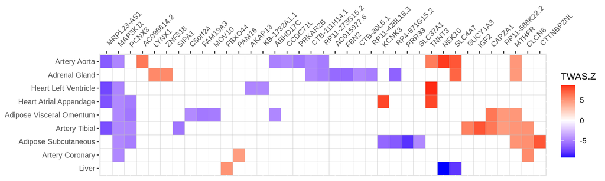

```r
#Clustering
twas.res_ht_matrix <-
  twas.res_ht %>%
  select(Gene,Tissue, TWAS.Z) %>%
  pivot_wider(names_from = "Gene", values_from=TWAS.Z) %>%
  column_to_rownames("Tissue") %>%
  mutate_all(~if_else(is.na(.),0,.)) %>% #To allow ordering by clusters
  as.matrix

ord_tissue <- hclust(dist(twas.res_ht_matrix))$order
ord_gene <- hclust(dist(t(twas.res_ht_matrix)))$order

#Plot
twas_plot <- twas.res_ht %>%
  select(Tissue, Gene, TWAS.Z) %>%
  #trick to fill empty cells with NA to get those coloured white
  pivot_wider(names_from=Tissue, values_from=TWAS.Z) %>%
  pivot_longer(!Gene, names_to="Tissue", values_to = "TWAS.Z") %>%
  #Order by clusters
  mutate(Tissue = factor(Tissue, levels = rownames(twas.res_ht_matrix)[ord_tissue])) %>%
  mutate(Gene = factor(Gene, levels = colnames(twas.res_ht_matrix)[ord_gene])) %>%
  #The plot
  ggplot(aes(x = Gene, Tissue)) +
  geom_tile(aes(fill = TWAS.Z), color="gray") +
  scale_fill_gradient2(low="blue",  mid="white", high="red", na.value = "white") +
  scale_x_discrete(position="top") +
  scale_y_discrete(limits=rev) +
  theme(axis.text.x = element_text(angle = 45, hjust = -0.1),
        axis.title = element_blank())

#ggsave(twas_plot, str_glue("{results_dir}/resht_twas_r12.jpg"), width=10, height=3)
#ggsave(twas_plot, str_glue("{results_dir}/resht_twas_r12.pdf"), width=10, height=3)

twas_plot
```

## 5.3 Mendelian randomization

Mendelian randomization software TwoSampleMR required internet connection and was run *at the local computer*:

```bash
Rscript scripts/run_MR_r12.R
```

Figures were uploaded:

**RES_HT**

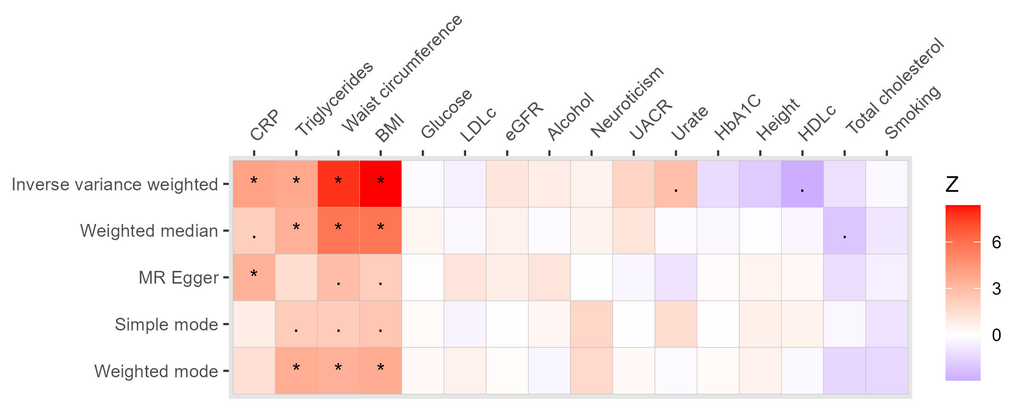

**HYPTENS**

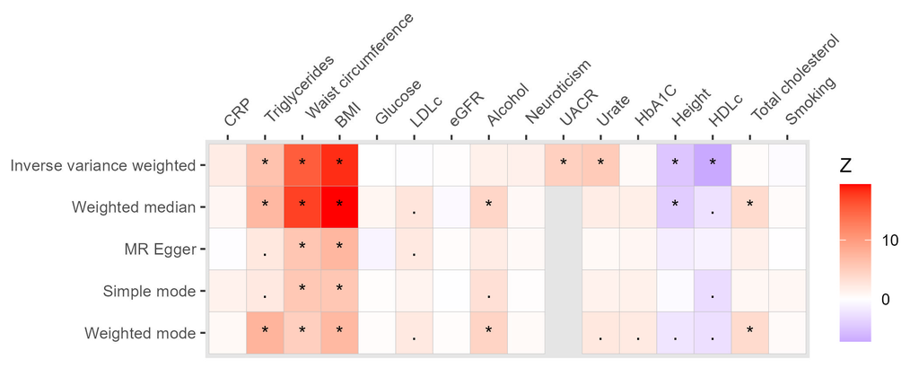

## 5.4 Risk traits

We used TwoSampleMR package to download and harmonize GWAS summaries. UACR was downloaded manually from GWAS catalog. TwoSampleMR requires internet connection and was run *at the local computer*.

```bash
Rscript scripts/risk_traits_plot.R
```

Figure was uploaded:

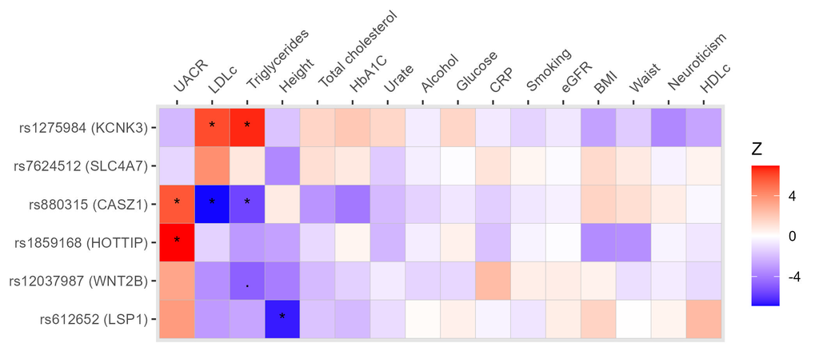